# Disaster Relief Project 2

#### 4.4.2.2 Holdout Set Performance

The holdout set data was tested using the trained QDA models.

The QDA standard model holdout performance was conducted with the best determined threshold of 0.75, as determined by the training set, and returned an accuracy of 99.526% with an FNR of 0.019% and FPR of 48.262%. The AUC was 0.99224. The holdout data performed better than the training data in terms of accuracy. The FPR rate, however, was much higher than the training performance. Due to the high FPR, this algorithm would not be recommended to predict the location of blue tarps from aerial images.

The QDA interaction model produced similar results with an accuracy of 99.526% with an FNR of 0.019% and FPR of 48.262% at a threshold of 0.05. The AUC was 0.96773. The high FPR suggested this algorithm should not be used for predicting whether or not a pixel contains a blue tarp.

```r
qda.cm <- cm(qda.fit, qda.thres)
qda.cm
```

```
#> Confusion Matrix and Statistics
#>
#>           Reference
#> Prediction      No     Yes
#>        No  1989319    9134
#>        Yes     378    9792
#>
#>                Accuracy : 0.9953
#>                  95% CI : (0.9952, 0.9954)
#>     No Information Rate : 0.9906
#>     P-Value [Acc > NIR] : < 2.2e-16
#>
#>                   Kappa : 0.6709
#>
#>  Mcnemar's Test P-Value : < 2.2e-16
#>
#>             Sensitivity : 0.9998
#>             Specificity : 0.5174
#>          Pos Pred Value : 0.9954
#>          Neg Pred Value : 0.9628
#>              Prevalence : 0.9906
#>          Detection Rate : 0.9904
#>    Detection Prevalence : 0.9949
#>       Balanced Accuracy : 0.7586
#>
#>        'Positive' Class : No
#>
```

```r
qda.cm.i <- cm(qda.fit, qda.thres)
qda.cm.i
```

```
#> Confusion Matrix and Statistics
#>
#>           Reference
#> Prediction      No     Yes
#>        No  1989319    9134
#>        Yes     378    9792
#>
#>                Accuracy : 0.9953
#>                  95% CI : (0.9952, 0.9954)
#>     No Information Rate : 0.9906
#>     P-Value [Acc > NIR] : < 2.2e-16
#>
#>                   Kappa : 0.6709
#>
#>  Mcnemar's Test P-Value : < 2.2e-16
#>
#>             Sensitivity : 0.9998
#>             Specificity : 0.5174
#>          Pos Pred Value : 0.9954
#>          Neg Pred Value : 0.9628
#>              Prevalence : 0.9906
#>          Detection Rate : 0.9904
#>    Detection Prevalence : 0.9949
#>       Balanced Accuracy : 0.7586
#>
#>        'Positive' Class : No
#>
```

```r
# ROC
qda.holdout <- holdoutperf(qda.fit, "QDA Standard Model Holdout ROC",
                           qda.thres)
qda.holdout.i <- holdoutperf(qda.fit.i, "QDA Interaction Model Holdout ROC",
                             qda.thres.i)
# AUC
qda.holdout
```

```
#> [1] 0.9922366
```

```r
qda.holdout.i
```

```
#> [1] 0.9677254
```

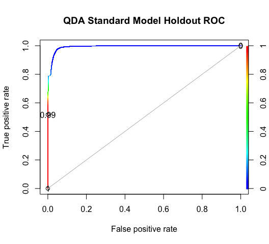

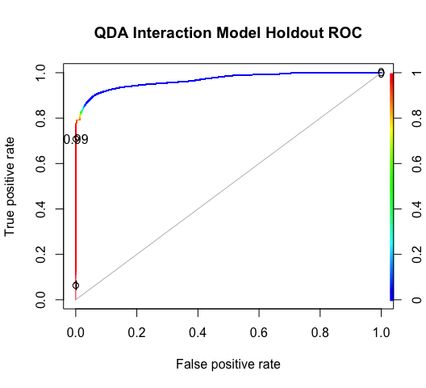

QDA Model ROCs - Holdout Set

## 4.5 KNN (K-Nearest Neighbors)

To prepare for using the K-Nearest Neighbors (KNN) method to predict whether or not a pixel contained a blue tarp, the $k$-value needed to be determined. A range of $k$-values, 1 to 25, were used to identify the best value, chosen by the $k$-value returning the lowest overall error rate and highest accuracy.

```r
k <- 1:25
```

### 4.5.1 Model Training

A standard three-variable model and interaction model were generated using KNN. To generate the model, `tuneGrid` needed to be set as a range of values to test and determine the best value for $k$. `expand.grid(k = 1:25)` was passed into the `model` function to test $k$ as the values from 1 to 25. `metric = "Accuracy"` was also passed to ensure the best model recommended had the highest accuracy.

The best $k$-value for the standard KNN regression had $k = 5$ as the optimal $k$-value. $k = 1$ was determined to be the best $k$-value for the interaction model.

```r
knn.fit <- model(Bluetarp ~ ., 'knn', expand.grid(k = k),
                 metric = "Accuracy")
knn.fit$finalModel
```

```
#> 5-nearest neighbor model
#> Training set outcome distribution:
#>
#>    No   Yes
#> 61219  2022
```

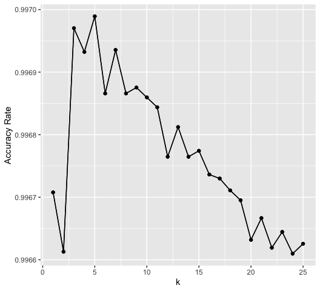

KNN Standard Model K-Value vs. Accuracy Rate

```r
ggplot(knn.fit, aes(x = k, y = knn.fit$results['Accuracy'])) +
  geom_point() +
  geom_line() +
  labs(x = "k", y = "Accuracy Rate")
```

```r
knn.fit.i <- model(Bluetarp ~ . + Green:Blue, 'knn',
                   expand.grid(k = k), metric = "Accuracy")
knn.fit.i$finalModel
```

```
#> 1-nearest neighbor model
#> Training set outcome distribution:
#>
#>    No   Yes
#> 61219  2022
```

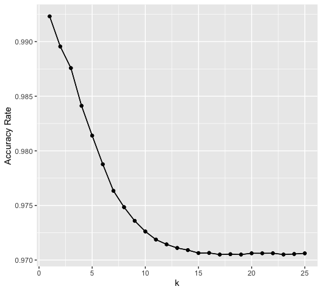

```r
ggplot(knn.fit.i, aes(x = k, y = knn.fit.i$results['Accuracy'])) +
  geom_point() +
  geom_line() +
  labs(x = "k", y = "Accuracy Rate")
```

### 4.5.2 Model Performance

#### 4.5.2.1 Training Set Performance

After model training, probability thresholds were calculated for the standard and interaction models.

The best probability threshold for the KNN standard model was determined to be best at 0.40 with $k=5$. This returned an accuracy of 99.701%, FNR of 0.164%, and FPR of 4.402. The AUC for this model was 0.99986. This model outperformed the logistic regression standard model and all other models previously investigated with the training set.

The KNN interaction model returned four thresholds with identical results. The selected threshold for the final model was 0.65 as the accuracy remained the highest when increasing the threshold, where lowering it to 0.5 had a lower accuracy if moving below 0.5. The KNN interaction model returned a training accuracy of 99.232%, FNR of 0.233%, and FPR of 16.954% with threshold 0.65 and $k=1$. The AUC was returned as 0.99997 This model did not perform as strongly as the KNN standard model, despite the higher AUC, and due to its lower performance in accuracy, FNR, and FPR would not be selected as the best algorithm for the training set.

```r
knn.thres <- threshold(knn.fit)
knn.thres.i <- threshold(knn.fit.i)

# determining best threshold row for highlighting
knn.best <- knn.thres %>%
  dplyr::select("prob_threshold", "Accuracy", "FNR", "FPR", "Dist", "F1") %>%
  slice(which.max(Accuracy)) %>%
  slice(which.min(FNR))
knn.bestrow <- which(knn.thres$Accuracy == knn.best$Accuracy)

knn.best.i <- knn.thres.i %>%
  dplyr::select("prob_threshold", "Accuracy", "FNR", "FPR", "Dist", "F1") %>%
  slice(which.max(Accuracy)) %>%
  slice(which.min(FNR)) %>%
  slice_max(prob_threshold)
knn.bestrow.i <- which(knn.thres.i$Accuracy == knn.best.i$Accuracy)

# table of threshold values
knn.thres %>%
    dplyr::select("prob_threshold", "Accuracy", "FNR", "FPR", "Dist", "F1") %>%
    knitr::kable(digits = 5,
                 caption = "KNN Standard Model Probability Threshold Table") %>%
    kableExtra::kable_styling(full_width = FALSE) %>%
    kableExtra::row_spec(row = knn.bestrow, bold = TRUE,
                         background = '#D3D3D3') %>%
    kable_styling(latex_options = "HOLD_position")
```

KNN Standard Model Probability Threshold Table

| prob_threshold | Accuracy | FNR | FPR | Dist | F1 |
| --- | --- | --- | --- | --- | --- |
| 0.05 | 0.99544 | 0.00040 | 0.13037 | 0.13037 | 0.99765 |
| 0.10 | 0.99545 | 0.00040 | 0.13027 | 0.13027 | 0.99765 |
| 0.15 | 0.99548 | 0.00042 | 0.12868 | 0.12869 | 0.99767 |
| 0.20 | 0.99667 | 0.00099 | 0.07438 | 0.07439 | 0.99828 |
| 0.25 | 0.99667 | 0.00099 | 0.07428 | 0.07429 | 0.99828 |
| 0.30 | 0.99666 | 0.00103 | 0.07329 | 0.07330 | 0.99827 |
| 0.35 | 0.99668 | 0.00111 | 0.07003 | 0.07004 | 0.99829 |
| 0.40 | 0.99701 | 0.00164 | 0.04402 | 0.04405 | 0.99845 |
| 0.45 | 0.99700 | 0.00166 | 0.04372 | 0.04375 | 0.99845 |
| 0.50 | 0.99699 | 0.00174 | 0.04154 | 0.04158 | 0.99844 |
| 0.55 | 0.99699 | 0.00174 | 0.04154 | 0.04158 | 0.99844 |
| 0.60 | 0.99657 | 0.00263 | 0.02740 | 0.02753 | 0.99823 |
| 0.65 | 0.99657 | 0.00264 | 0.02730 | 0.02743 | 0.99823 |
| 0.70 | 0.99652 | 0.00277 | 0.02483 | 0.02498 | 0.99820 |
| 0.75 | 0.99651 | 0.00280 | 0.02463 | 0.02479 | 0.99819 |
| 0.80 | 0.99573 | 0.00381 | 0.01820 | 0.01860 | 0.99779 |
| 0.85 | 0.99559 | 0.00399 | 0.01721 | 0.01767 | 0.99772 |
| 0.90 | 0.99558 | 0.00402 | 0.01662 | 0.01710 | 0.99771 |

```r
knn.thres.i %>%
    dplyr::select("prob_threshold", "Accuracy", "FNR", "FPR", "Dist", "F1") %>%
    knitr::kable(digits = 5,
                 caption = "KNN Interaction Model
                 Probability Threshold Table") %>%
    kableExtra::kable_styling(full_width = FALSE) %>%
    kableExtra::row_spec(row = knn.bestrow.i, bold = TRUE,
                         background = '#D3D3D3') %>%
    kable_styling(latex_options = "HOLD_position")
```

KNN Interaction Model Probability Threshold Table

| prob_threshold | Accuracy | FNR | FPR | Dist | F1 |
| --- | --- | --- | --- | --- | --- |
| 0.05 | 0.99229 | 0.00230 | 0.17161 | 0.17163 | 0.99602 |
| 0.10 | 0.99229 | 0.00230 | 0.17161 | 0.17163 | 0.99602 |
| 0.15 | 0.99229 | 0.00230 | 0.17161 | 0.17163 | 0.99602 |
| 0.20 | 0.99229 | 0.00230 | 0.17161 | 0.17163 | 0.99602 |
| 0.25 | 0.99229 | 0.00230 | 0.17161 | 0.17163 | 0.99602 |
| 0.30 | 0.99229 | 0.00230 | 0.17161 | 0.17163 | 0.99602 |
| 0.35 | 0.99229 | 0.00230 | 0.17151 | 0.17153 | 0.99602 |
| 0.40 | 0.99229 | 0.00230 | 0.17151 | 0.17153 | 0.99602 |
| 0.45 | 0.99229 | 0.00230 | 0.17151 | 0.17153 | 0.99602 |
| 0.50 | 0.99232 | 0.00233 | 0.16954 | 0.16955 | 0.99604 |
| 0.55 | 0.99232 | 0.00233 | 0.16954 | 0.16955 | 0.99604 |
| 0.60 | 0.99232 | 0.00233 | 0.16954 | 0.16955 | 0.99604 |
| 0.65 | 0.99232 | 0.00233 | 0.16954 | 0.16955 | 0.99604 |
| 0.70 | 0.99232 | 0.00234 | 0.16954 | 0.16955 | 0.99604 |
| 0.75 | 0.99232 | 0.00234 | 0.16954 | 0.16955 | 0.99604 |
| 0.80 | 0.99232 | 0.00234 | 0.16954 | 0.16955 | 0.99604 |
| 0.85 | 0.99232 | 0.00234 | 0.16954 | 0.16955 | 0.99604 |
| 0.90 | 0.99232 | 0.00234 | 0.16954 | 0.16955 | 0.99604 |

```r
# ROC
knn.ROC <- ROC(knn.fit, "KNN Standard Model Training ROC", knn.thres)
```

```
#> Confusion Matrix and Statistics
#>
#>           Reference
#> Prediction    No   Yes
#>        No  61219   241
#>        Yes     0  1781
#>
#>                Accuracy : 0.9962
#>                  95% CI : (0.9957, 0.9967)
#>     No Information Rate : 0.968
#>     P-Value [Acc > NIR] : < 2.2e-16
#>
#>                   Kappa : 0.9347
#>
#>  Mcnemar's Test P-Value : < 2.2e-16
#>
#>             Sensitivity : 1.0000
#>             Specificity : 0.8808
#>          Pos Pred Value : 0.9961
#>          Neg Pred Value : 1.0000
#>              Prevalence : 0.9680
#>          Detection Rate : 0.9680
#>    Detection Prevalence : 0.9718
#>       Balanced Accuracy : 0.9404
#>
#>        'Positive' Class : No
#>
```

```r
knn.ROC.i <- ROC(knn.fit.i, "KNN Interaction Model Training ROC", knn.thres.i)
```

```
#> Confusion Matrix and Statistics
#>
#>           Reference
#> Prediction    No   Yes
#>        No  61219    26
#>        Yes     0  1996
#>
#>                Accuracy : 0.9996
#>                  95% CI : (0.9994, 0.9997)
#>     No Information Rate : 0.968
#>     P-Value [Acc > NIR] : < 2.2e-16
#>
#>                   Kappa : 0.9933
#>
#>  Mcnemar's Test P-Value : 9.443e-07
#>
#>             Sensitivity : 1.0000
#>             Specificity : 0.9871
#>          Pos Pred Value : 0.9996
#>          Neg Pred Value : 1.0000
#>              Prevalence : 0.9680
#>          Detection Rate : 0.9680
#>    Detection Prevalence : 0.9684
#>       Balanced Accuracy : 0.9936
#>
#>        'Positive' Class : No
#>
```

```r
#AUC
knn.ROC
```

```
#> [1] 0.9998582
```

```r
knn.ROC.i
```

```
#> [1] 0.9999734
```

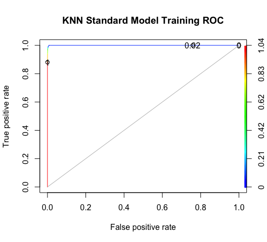

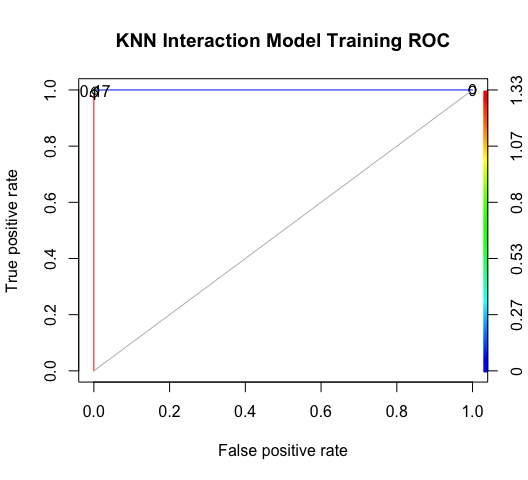

KNN Model ROCs - Training Set

#### 4.5.2.2 Holdout Set Performance

After training the KNN models, performance was tested for both the standard and interaction models using the holdout set with the same thresholds and $k$-values as their respective training performance testing.

The KNN standard model’s holdout performance resulted in an accuracy of 99.454%, FNR of 0.269%, and FPR of 29.658%. The AUC was 0.95986. This algorithm did not perform as well with the holdout data as it did with the training data. This suggested over training may be present. The most noticeable performance difference between data sets was with FPR, which increased from 4.402% in the training set to 29.658% with the holdout set. Although the KNN standard model’s performance with the training set was the best thus far, this dramatic change when testing with the holdout set was concerning.

The KNN interaction model, on the other hand, returned better accuracy than its training performance, but a much lower AUC and worse FNR and FPR. In fact, the accuracy, FNR, and FPR were the same as the performance from the KNN standard model with the holdout set. The holdout performance returned an accuracy of 99.454%, FNR of 0.269%, and FPR of 29.658%. The AUC, however, was much lower than the KNN standard model’s test performance, resulting in an AUC of 0.87348. This was evidence that the KNN interaction algorithm may not be appropriate for predicting blue tarps when using the holdout set.

```r
knn.cm <- cm(knn.fit, knn.thres)
knn.cm
```

```
#> Confusion Matrix and Statistics
#>
#>           Reference
#> Prediction      No     Yes
#>        No  1984345    5613
#>        Yes    5352   13313
#>
#>                Accuracy : 0.9945
#>                  95% CI : (0.9944, 0.9946)
#>     No Information Rate : 0.9906
#>     P-Value [Acc > NIR] : < 2e-16
#>
#>                   Kappa : 0.7056
#>
#>  Mcnemar's Test P-Value : 0.01303
#>
#>             Sensitivity : 0.9973
#>             Specificity : 0.7034
#>          Pos Pred Value : 0.9972
#>          Neg Pred Value : 0.7133
#>              Prevalence : 0.9906
#>          Detection Rate : 0.9879
#>    Detection Prevalence : 0.9907
#>       Balanced Accuracy : 0.8504
#>
#>        'Positive' Class : No
#>
```

```r
knn.cm.i <- cm(knn.fit, knn.thres)
knn.cm.i
```

```
#> Confusion Matrix and Statistics
#>
#>           Reference
#> Prediction      No     Yes
#>        No  1984345    5613
#>        Yes    5352   13313
#>
#>                Accuracy : 0.9945
#>                  95% CI : (0.9944, 0.9946)
#>     No Information Rate : 0.9906
#>     P-Value [Acc > NIR] : < 2e-16
#>
#>                   Kappa : 0.7056
#>
#>  Mcnemar's Test P-Value : 0.01303
#>
#>             Sensitivity : 0.9973
#>             Specificity : 0.7034
#>          Pos Pred Value : 0.9972
#>          Neg Pred Value : 0.7133
#>              Prevalence : 0.9906
#>          Detection Rate : 0.9879
#>    Detection Prevalence : 0.9907
#>       Balanced Accuracy : 0.8504
#>
#>        'Positive' Class : No
#>
```

```r
# ROC
knn.holdout <- holdoutperf(knn.fit, "KNN Standard Model Holdout ROC",
                           knn.thres)
knn.holdout.i <- holdoutperf(knn.fit.i, "KNN Interaction Model Holdout ROC",
                             knn.thres.i)

# AUC
knn.holdout
```

```
#> [1] 0.9598593
```

```r
knn.holdout.i
```

```
#> [1] 0.8734827
```

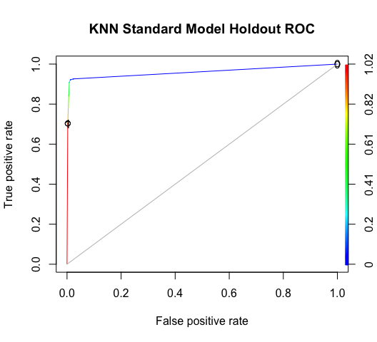

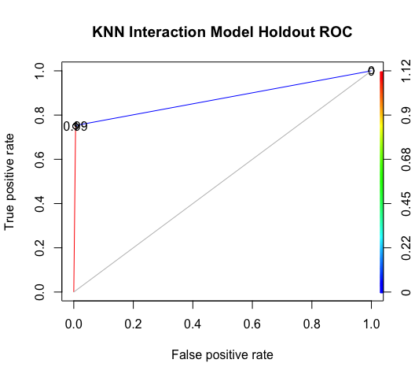

KNN Model ROCs - Holdout Set

## 4.6 Penalized Logistic Regression (Elastic Net Penalty)

With there being only few variables included in the model, the selected type of penalized logistic regression model was tuned with ridge regression.

Before creating the ridge regression models, an additional tuning parameter, $\lambda$ needed to be prepared and passed in the function `model`.

```r
lambdas <- 10^seq(-2, -3, by = -0.05)
tuneGrid <- expand.grid(alpha = 0, # selected 0 for ridge regression
                        lambda = lambdas)
```

### 4.6.1 Model Training

The standard, three-variable model was generated first. The best accuracy was returned with the tuning parameter set to $\lambda = 0.00398$. The interaction model was also generated. The final tuning parameter value for the interaction model $\lambda = 0.00398$.

```r
ridge.fit <- model(Bluetarp ~ ., 'glmnet', tuneGrid)
ridge.fit
```

```
#> glmnet
#>
#> 63241 samples
#>     3 predictor
#>     2 classes: 'No', 'Yes'
#>
#> No pre-processing
#> Resampling: Cross-Validated (10 fold)
#> Summary of sample sizes: 31621, 31621, 31621, 31621, 31621, 31621, ...
#> Resampling results across tuning parameters:
#>
#>   lambda       Accuracy   Kappa
#>   0.001000000  0.9781657  0.4732998385
#>   0.001122018  0.9781657  0.4732998385
#>   0.001258925  0.9781657  0.4732998385
#>   0.001412538  0.9781657  0.4732998385
#>   0.001584893  0.9781657  0.4732998385
#>   0.001778279  0.9781657  0.4732998385
#>   0.001995262  0.9781657  0.4732998385
#>   0.002238721  0.9781657  0.4732998385
#>   0.002511886  0.9781657  0.4732998385
#>   0.002818383  0.9781657  0.4732998385
#>   0.003162278  0.9781657  0.4732998385
#>   0.003548134  0.9781657  0.4732998385
#>   0.003981072  0.9781657  0.4732998385
#>   0.004466836  0.9769355  0.4276860893
#>   0.005011872  0.9748482  0.3441657254
#>   0.005623413  0.9728463  0.2556373994
#>   0.006309573  0.9709424  0.1625996907
#>   0.007079458  0.9696110  0.0915949808
#>   0.007943282  0.9686970  0.0397745325
#>   0.008912509  0.9680424  0.0009562548
#>   0.010000000  0.9680266  0.0000000000
#>
#> Tuning parameter 'alpha' was held constant at a value of 0
#> Accuracy was used to select the optimal model using the largest value.
#> The final values used for the model were alpha = 0 and lambda = 0.003981072.
```

```r
ridge.fit.i <- model(Bluetarp ~ . + Green:Blue, 'glmnet', tuneGrid)
ridge.fit.i
```

```
#> glmnet
#>
#> 63241 samples
#>     3 predictor
#>     2 classes: 'No', 'Yes'
#>
#> No pre-processing
#> Resampling: Cross-Validated (10 fold)
#> Summary of sample sizes: 31621, 31621, 31621, 31621, 31621, 31621, ...
#> Resampling results across tuning parameters:
#>
#>   lambda       Accuracy   Kappa
#>   0.001000000  0.9788109  0.496183101
#>   0.001122018  0.9788109  0.496183101
#>   0.001258925  0.9788109  0.496183101
#>   0.001412538  0.9788109  0.496183101
#>   0.001584893  0.9788109  0.496183101
#>   0.001778279  0.9788109  0.496183101
#>   0.001995262  0.9788109  0.496183101
#>   0.002238721  0.9788109  0.496183101
#>   0.002511886  0.9788109  0.496183101
#>   0.002818383  0.9788109  0.496183101
#>   0.003162278  0.9788109  0.496183101
#>   0.003548134  0.9788109  0.496183101
#>   0.003981072  0.9788109  0.496183101
#>   0.004466836  0.9777483  0.458093576
#>   0.005011872  0.9760342  0.392618390
#>   0.005623413  0.9740070  0.308028941
#>   0.006309573  0.9718438  0.207704184
#>   0.007079458  0.9700348  0.114738487
#>   0.007943282  0.9689658  0.055299771
#>   0.008912509  0.9681499  0.007434766
#>   0.010000000  0.9680266  0.000000000
#>
#> Tuning parameter 'alpha' was held constant at a value of 0
#> Accuracy was used to select the optimal model using the largest value.
#> The final values used for the model were alpha = 0 and lambda = 0.003981072.
```

Despite these findings, the model was generated using $\lambda = 0.00398$ to conduct thorough method analysis.

### 4.6.2 Model Performance

#### 4.6.2.1 Training Set Performance

Model performance was tested by first calculating the appropriate probability threshold. The standard model performed best with a probability threshold of 0.75, resulting in an accuracy of 98.623%, FNR of 0.051%, and FPR of 41.503%. The interaction model’s best performing probability threshold was 0.70, with an accuracy of 98.525%, 0.000% FNR, and 46.133% FPR.

The ROC and AUC were computed for both ridge regression models. The three-variable model’s AUC was 0.98019 while the interaction model’s AUC was 0.97814.

Neither the standard model nor the interaction model using ridge regression performed well with the training performance, as expected, and would not be recommended for the training data.

```r
ridge.thres <- threshold(ridge.fit)
ridge.thres.i <- threshold(ridge.fit.i)

# determining best threshold row for highlighting
ridge.best <- ridge.thres %>%
  dplyr::select("prob_threshold", "Accuracy", "FNR", "FPR", "Dist", "F1") %>%
  slice(which.max(Accuracy)) %>%
  slice(which.min(FNR))
ridge.bestrow <- which(ridge.thres$Accuracy == ridge.best$Accuracy)

ridge.best.i <- ridge.thres.i %>%
  dplyr::select("prob_threshold", "Accuracy", "FNR", "FPR", "Dist", "F1") %>%
  slice(which.max(Accuracy)) %>%
  slice(which.min(FNR))
ridge.bestrow.i <- which(ridge.thres.i$Accuracy == ridge.best.i$Accuracy)

# table of threshold values
ridge.thres %>%
    dplyr::select("prob_threshold", "Accuracy", "FNR", "FPR", "Dist", "F1") %>%
    knitr::kable(digits = 5,
                 caption = "Ridge Regression Standard Model
                 Probability Threshold Table") %>%
    kableExtra::kable_styling(full_width = FALSE) %>%
    kableExtra::row_spec(row = ridge.bestrow, bold = TRUE,
                         background = '#D3D3D3') %>%
    kable_styling(latex_options = "HOLD_position")
```

Ridge Regression Standard Model Probability Threshold Table

| prob_threshold | Accuracy | FNR | FPR | Dist | F1 |
| --- | --- | --- | --- | --- | --- |
| 0.05 | 0.96803 | 0.00000 | 1.00000 | 1.00000 | 0.98375 |
| 0.10 | 0.96803 | 0.00000 | 1.00000 | 1.00000 | 0.98375 |
| 0.15 | 0.96803 | 0.00000 | 1.00000 | 1.00000 | 0.98375 |
| 0.20 | 0.96805 | 0.00000 | 0.99941 | 0.99941 | 0.98376 |
| 0.25 | 0.96864 | 0.00000 | 0.98081 | 0.98081 | 0.98406 |
| 0.30 | 0.96954 | 0.00000 | 0.95272 | 0.95272 | 0.98451 |
| 0.35 | 0.97083 | 0.00000 | 0.91227 | 0.91227 | 0.98516 |
| 0.40 | 0.97286 | 0.00000 | 0.84896 | 0.84896 | 0.98617 |
| 0.45 | 0.97520 | 0.00000 | 0.77577 | 0.77577 | 0.98735 |
| 0.50 | 0.97817 | 0.00000 | 0.68289 | 0.68289 | 0.98885 |
| 0.55 | 0.98058 | 0.00000 | 0.60732 | 0.60732 | 0.99007 |
| 0.60 | 0.98224 | 0.00000 | 0.55549 | 0.55549 | 0.99091 |
| 0.65 | 0.98351 | 0.00000 | 0.51583 | 0.51583 | 0.99155 |
| 0.70 | 0.98503 | 0.00000 | 0.46815 | 0.46815 | 0.99233 |
| 0.75 | 0.98623 | 0.00051 | 0.41503 | 0.41504 | 0.99294 |
| 0.80 | 0.98282 | 0.00666 | 0.33541 | 0.33548 | 0.99115 |
| 0.85 | 0.98265 | 0.00959 | 0.25213 | 0.25231 | 0.99103 |
| 0.90 | 0.97978 | 0.01488 | 0.18200 | 0.18261 | 0.98951 |

```r
ridge.thres.i %>%
    dplyr::select("prob_threshold", "Accuracy", "FNR", "FPR", "Dist", "F1") %>%
    knitr::kable(digits = 5,
                 caption = "Ridge Regression Interaction Model
                 Probability Threshold Table") %>%
    kableExtra::kable_styling(full_width = FALSE) %>%
    kableExtra::row_spec(row = ridge.bestrow.i, bold = TRUE,
                         background = '#D3D3D3') %>%
    kable_styling(latex_options = "HOLD_position")
```

Ridge Regression Interaction Model Probability Threshold Table

| prob_threshold | Accuracy | FNR | FPR | Dist | F1 |
| --- | --- | --- | --- | --- | --- |
| 0.05 | 0.96803 | 0.00000 | 1.00000 | 1.00000 | 0.98375 |
| 0.10 | 0.96803 | 0.00000 | 1.00000 | 1.00000 | 0.98375 |
| 0.15 | 0.96803 | 0.00000 | 1.00000 | 1.00000 | 0.98375 |
| 0.20 | 0.96804 | 0.00000 | 0.99970 | 0.99970 | 0.98376 |
| 0.25 | 0.96868 | 0.00000 | 0.97943 | 0.97943 | 0.98408 |
| 0.30 | 0.96961 | 0.00000 | 0.95045 | 0.95045 | 0.98455 |
| 0.35 | 0.97106 | 0.00000 | 0.90524 | 0.90524 | 0.98527 |
| 0.40 | 0.97346 | 0.00000 | 0.83017 | 0.83017 | 0.98648 |
| 0.45 | 0.97621 | 0.00000 | 0.74402 | 0.74402 | 0.98786 |
| 0.50 | 0.97881 | 0.00000 | 0.66271 | 0.66271 | 0.98917 |
| 0.55 | 0.98126 | 0.00000 | 0.58615 | 0.58615 | 0.99041 |
| 0.60 | 0.98277 | 0.00000 | 0.53897 | 0.53897 | 0.99118 |
| 0.65 | 0.98381 | 0.00000 | 0.50633 | 0.50633 | 0.99171 |
| 0.70 | 0.98525 | 0.00000 | 0.46133 | 0.46133 | 0.99244 |
| 0.75 | 0.98134 | 0.00567 | 0.41187 | 0.41191 | 0.99040 |
| 0.80 | 0.98164 | 0.00744 | 0.34876 | 0.34884 | 0.99054 |
| 0.85 | 0.98106 | 0.01055 | 0.27290 | 0.27310 | 0.99021 |
| 0.90 | 0.97833 | 0.01593 | 0.19545 | 0.19610 | 0.98876 |

```r
# ROC
ridge.ROC <- ROC(ridge.fit,
                 "Ridge Regresion Standard Model Training ROC",
                 ridge.thres)
```

```
#> Confusion Matrix and Statistics
#>
#>           Reference
#> Prediction    No   Yes
#>        No  61219  2022
#>        Yes     0     0
#>
#>                Accuracy : 0.968
#>                  95% CI : (0.9666, 0.9694)
#>     No Information Rate : 0.968
#>     P-Value [Acc > NIR] : 0.5059
#>
#>                   Kappa : 0
#>
#>  Mcnemar's Test P-Value : <2e-16
#>
#>             Sensitivity : 1.000
#>             Specificity : 0.000
#>          Pos Pred Value : 0.968
#>          Neg Pred Value :   NaN
#>              Prevalence : 0.968
#>          Detection Rate : 0.968
#>    Detection Prevalence : 1.000
#>       Balanced Accuracy : 0.500
#>
#>        'Positive' Class : No
#>
```

```r
ridge.ROC.i <- ROC(ridge.fit.i,
                   "Ridge Regression Interaction Model Training ROC",
                   ridge.thres.i)
```

```
#> Confusion Matrix and Statistics
#>
#>           Reference
#> Prediction    No   Yes
#>        No  61219  2022
#>        Yes     0     0
#>
#>                Accuracy : 0.968
#>                  95% CI : (0.9666, 0.9694)
#>     No Information Rate : 0.968
#>     P-Value [Acc > NIR] : 0.5059
#>
#>                   Kappa : 0
#>
#>  Mcnemar's Test P-Value : <2e-16
#>
#>             Sensitivity : 1.000
#>             Specificity : 0.000
#>          Pos Pred Value : 0.968
#>          Neg Pred Value :   NaN
#>              Prevalence : 0.968
#>          Detection Rate : 0.968
#>    Detection Prevalence : 1.000
#>       Balanced Accuracy : 0.500
#>
#>        'Positive' Class : No
#>
```

```r
# AUC
ridge.ROC
```

```
#> [1] 0.9801948
```

```r
ridge.ROC.i
```

```
#> [1] 0.9781388
```

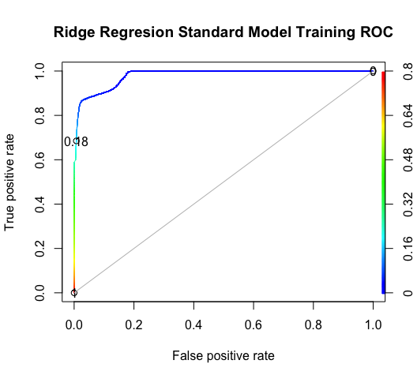

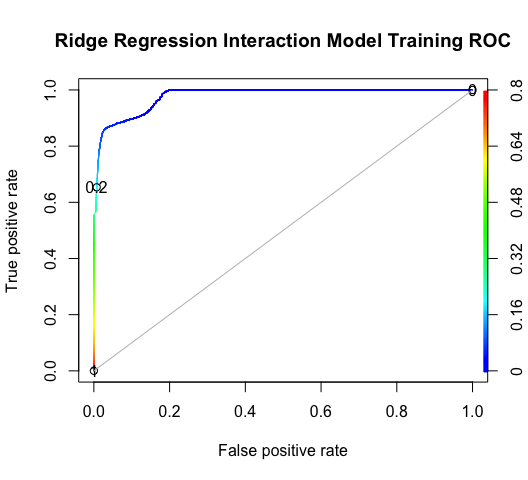

Ridge Regression Model ROCs - Training Set

#### 4.6.2.2 Holdout Set Performance

Holdout performance was still executed to collect and complete the results for comparison of all model performances.

The ridge regression standard model’s test accuracy was calculated to 99.058% with an FNR of 0.000% and FPR of 100%. The AUC was 0.98815. The accuracy and AUC are very misleading as the FPR was 100%, confirming this model does not perform well and is not a good fit for predicting blue tarps in disaster relief situations.

The interaction ridge regression model returned similar results as the standard model with an accuracy of 99.058%, FNR of 0.000% and FPR of 100%. The AUC was 0.98682.

As previously discussed, these models are not performing to the same standards at the other models and would not be considered for predicting blue tarps in the event of emergency based on holdout performance.

```r
ridge.cm <- cm(ridge.fit, ridge.thres)
ridge.cm
```

```
#> Confusion Matrix and Statistics
#>
#>           Reference
#> Prediction      No     Yes
#>        No  1989697   18926
#>        Yes       0       0
#>
#>                Accuracy : 0.9906
#>                  95% CI : (0.9904, 0.9907)
#>     No Information Rate : 0.9906
#>     P-Value [Acc > NIR] : 0.5019
#>
#>                   Kappa : 0
#>
#>  Mcnemar's Test P-Value : <2e-16
#>
#>             Sensitivity : 1.0000
#>             Specificity : 0.0000
#>          Pos Pred Value : 0.9906
#>          Neg Pred Value :    NaN
#>              Prevalence : 0.9906
#>          Detection Rate : 0.9906
#>    Detection Prevalence : 1.0000
#>       Balanced Accuracy : 0.5000
#>
#>        'Positive' Class : No
#>
```

```r
ridge.cm.i <- cm(ridge.fit, ridge.thres)
ridge.cm.i
```

```
#> Confusion Matrix and Statistics
#>
#>           Reference
#> Prediction      No     Yes
#>        No  1989697   18926
#>        Yes       0       0
#>
#>                Accuracy : 0.9906
#>                  95% CI : (0.9904, 0.9907)
#>     No Information Rate : 0.9906
#>     P-Value [Acc > NIR] : 0.5019
#>
#>                   Kappa : 0
#>
#>  Mcnemar's Test P-Value : <2e-16
#>
#>             Sensitivity : 1.0000
#>             Specificity : 0.0000
#>          Pos Pred Value : 0.9906
#>          Neg Pred Value :    NaN
#>              Prevalence : 0.9906
#>          Detection Rate : 0.9906
#>    Detection Prevalence : 1.0000
#>       Balanced Accuracy : 0.5000
#>
#>        'Positive' Class : No
#>
```

```r
# ROC
ridge.holdout <- holdoutperf(ridge.fit,
            "Ridge Regresion Standard Model Holdout ROC", ridge.thres)
ridge.holdout.i <- holdoutperf(ridge.fit.i,
            "Ridge Regresion Interaction Model Training ROC", ridge.thres.i)

# AUC
ridge.holdout
```

```
#> [1] 0.9881507
```

```r
ridge.holdout.i
```

```
#> [1] 0.9868176
```

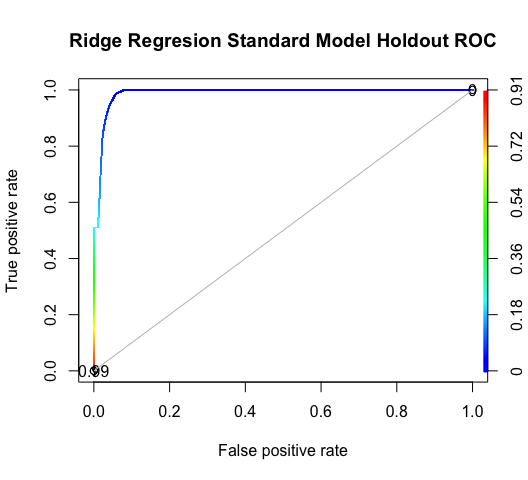

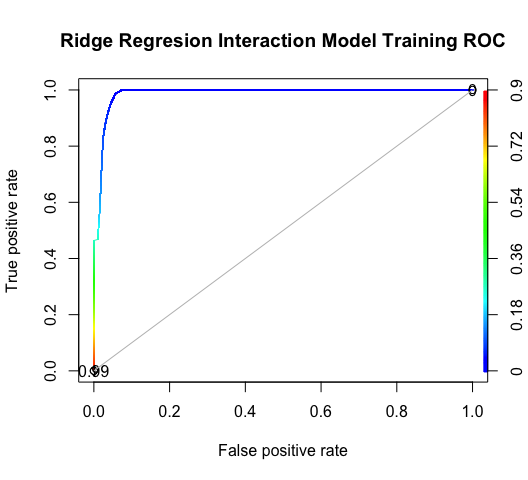

Ridge Regression Model ROCs - Holdout Set

## 4.7 Random Forest

Random forest models have more requirements than the previously demonstrated models. To train the random forest models the appropriate `mtry` and `ntree` values needed to be determined. To determine these values a `for` loop was utilized and a table generated to compare the results. Visualizations were also generated to identify what parameters returned the best standard and interaction random forest models.

Comparison of the Out-of-Bag Mean Square Error (OOB MSE) was observed visually and a table compared all of the results, returning the optimal parameters. For the standard model, the parameters that returned the lowest OOB MSE was `ntree = 41` and `mtry = 2`, which had an OOB MSE of 0.275%. The interaction model returned a minimum OOB MSE of 00.275% when the parameters were set to `ntree = 472` and `mtry = 1`.

```r
set.seed(1)
rf.results = tibble()
for (mtry in 1:(ncol(Train) - 1)) {
  rf.try <- model(Bluetarp ~., 'rf', expand.grid(mtry = mtry), ntree = 500)
  rf.results <- bind_rows(rf.results,
                          tibble(oob_mse = rf.try$finalModel$err.rate[,1],
                                 ntree = 1:500,
                                 mtry = mtry))
}
```

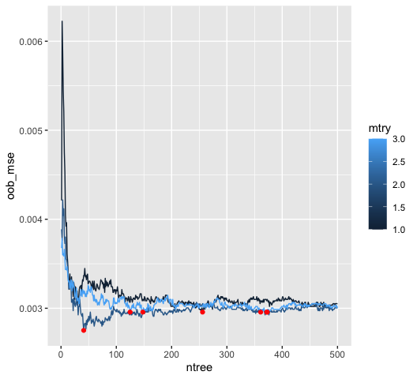

Random Forest Standard Model Parameter Selection

```r
rf.minima <- rf.results %>%
  group_by(mtry) %>%
  filter(oob_mse == min(oob_mse))
ggplot(rf.results, aes(x = ntree, y = oob_mse, color = mtry, group = mtry)) +
  geom_line() +
  geom_point(data = rf.minima, color = 'red')
```

```r
rf.params <- rf.results %>%
  dplyr::slice_min(oob_mse)

rf.params %>%
  knitr::kable(digits = 5, caption = "Random Forest Standard Model
               Lowest Threshold") %>%
  kableExtra::kable_styling(full_width = FALSE) %>%
  kable_styling(latex_options = "HOLD_position")
```

Random Forest Standard Model Lowest Threshold

| oob_mse | ntree | mtry |
| --- | --- | --- |
| 0.00275 | 41 | 2 |

```r
set.seed(1)
rf.results.i = tibble()
for (mtry in 1:(ncol(Train) - 1)) {
  rf.try.i <- model(Bluetarp ~ . + Green:Blue, 'rf', expand.grid(mtry = mtry),
                    ntree = 500)
  rf.results.i <- bind_rows(rf.results.i,
                          tibble(oob_mse.i = rf.try.i$finalModel$err.rate[,1],
                                 ntree = 1:500,
                                 mtry = mtry))
}
```

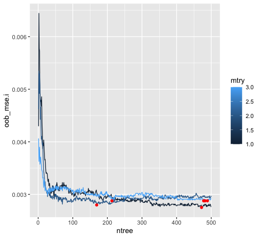

Random Forest Interaction Model Parameter Selection

```r
rf.minima.i <- rf.results.i %>%
  group_by(mtry) %>%
  filter(oob_mse.i == min(oob_mse.i))
ggplot(rf.results.i, aes(x = ntree, y = oob_mse.i, color = mtry, group = mtry)) +
  geom_line() +
  geom_point(data = rf.minima.i, color = 'red')
```

```r
rf.i.params <- rf.results.i %>%
  dplyr::slice_min(oob_mse.i)

rf.i.params %>%
  knitr::kable(digits = 5, caption = "Random Forest Interaction Model
               Lowest Threshold") %>%
  kableExtra::kable_styling(full_width = FALSE) %>%
  kable_styling(latex_options = "HOLD_position")
```

Random Forest Interaction Model Lowest Threshold

| oob_mse.i | ntree | mtry |
| --- | --- | --- |
| 0.00275 | 472 | 1 |

### 4.7.1 Model Training

These best parameters were then piped into the `model` function to build the model before conducting performance tests on both the training and holdout sets.

```r
rf.fit <- model(Bluetarp ~., 'rf', expand.grid(mtry = rf.params['mtry']),
                ntree = rf.params['ntree'])
rf.fit
```

```
#> Random Forest
#>
#> 63241 samples
#>     3 predictor
#>     2 classes: 'No', 'Yes'
#>
#> No pre-processing
#> Resampling: Cross-Validated (10 fold)
#> Summary of sample sizes: 31621, 31621, 31621, 31621, 31621, 31621, ...
#> Resampling results:
#>
#>   Accuracy   Kappa
#>   0.9968596  0.9490892
#>
#> Tuning parameter 'mtry' was held constant at a value of 2
```

```r
rf.fit.i <- model(Bluetarp ~. + Green:Blue, 'rf',
                  expand.grid(mtry = rf.i.params['mtry']),
                  ntree = rf.params.i['ntree'])
rf.fit.i
```

```
#> Random Forest
#>
#> 63241 samples
#>     3 predictor
#>     2 classes: 'No', 'Yes'
#>
#> No pre-processing
#> Resampling: Cross-Validated (10 fold)
#> Summary of sample sizes: 31621, 31621, 31621, 31621, 31621, 31621, ...
#> Resampling results:
#>
#>   Accuracy   Kappa
#>   0.9968469  0.9486146
#>
#> Tuning parameter 'mtry' was held constant at a value of 1
```

### 4.7.2 Model Performance

#### 4.7.2.1 Training Set Performance

Following model training, the best threshold was determined for both the random forest standard model and the random forest interaction model by passing the models into the `threshold` function. The best threshold for the standard model was determined to be 0.50 when `ntree = 41` and `mtry = 2`. The best threshold for the interaction model was calculated to 0.60 when `ntree = 472` and `mtry = 1`.

Using these thresholds, performance metrics were calculated. The random forest standard model returned an accuracy of 99.685%, FNR of 0.152%, and FPR of 5.252%. The AUC was 0.99450. Overall, this model appeared to be performing best with the training metrics, outperforming the logistic regression standard and interaction models in all areas except FPR, which was a little higher than the logistic regression interaction model’s FPR, but lower than the logistic regression standard model’s FPR. This model, however, did not perform as well as the KNN standard model.

The random forest interaction model, with a probability threshold of 0.60, returned an accuracy of 99.690%, FNR of 0.184%, and FPR of 4.115%. The AUC was 0.99994. This model had a slightly higher accuracy than the random forest standard model, but also a higher FNR and a lower FPR. This model would be considered comparable to the random forest standard model, but the standard model may be selected over the interaction model for the lower FNR and generally less complex model. Like it’s fellow standard model, this model did not perform as well as the front-running KNN standard model.

```r
rf.thres <- threshold(rf.fit)
rf.thres.i <- threshold(rf.fit.i)

# determining best threshold row for highlighting
rf.best <- rf.thres %>%
  dplyr::select("prob_threshold", "Accuracy", "FNR", "FPR", "Dist", "F1") %>%
  slice(which.max(Accuracy)) %>%
  slice(which.min(FNR))
rf.bestrow <- which(rf.thres$Accuracy == rf.best$Accuracy)

rf.best.i <- rf.thres.i %>%
  dplyr::select("prob_threshold", "Accuracy", "FNR", "FPR", "Dist", "F1") %>%
  slice(which.max(Accuracy)) %>%
  slice(which.min(FNR))
rf.bestrow.i <- which(rf.thres.i$Accuracy == rf.best.i$Accuracy)

# table of threshold values
rf.thres %>%
    dplyr::select("prob_threshold", "Accuracy", "FNR", "FPR", "Dist", "F1") %>%
    knitr::kable(digits = 5,
                 caption = "Random Forest Regression Standard Model
                 Probability Threshold Table") %>%
    kableExtra::kable_styling(full_width = FALSE) %>%
    kableExtra::row_spec(row = rf.bestrow, bold = TRUE,
                         background = '#D3D3D3') %>%
    kable_styling(latex_options = "HOLD_position")
```

Random Forest Regression Standard Model Probability Threshold Table

| prob_threshold | Accuracy | FNR | FPR | Dist | F1 |
| --- | --- | --- | --- | --- | --- |
| 0.05 | 0.99323 | 0.00014 | 0.20752 | 0.20752 | 0.99652 |
| 0.10 | 0.99452 | 0.00030 | 0.16222 | 0.16222 | 0.99718 |
| 0.15 | 0.99531 | 0.00043 | 0.13373 | 0.13373 | 0.99758 |
| 0.20 | 0.99590 | 0.00057 | 0.11118 | 0.11118 | 0.99788 |
| 0.25 | 0.99623 | 0.00066 | 0.09792 | 0.09793 | 0.99805 |
| 0.30 | 0.99642 | 0.00079 | 0.08793 | 0.08794 | 0.99815 |
| 0.35 | 0.99662 | 0.00093 | 0.07765 | 0.07765 | 0.99826 |
| 0.40 | 0.99676 | 0.00110 | 0.06815 | 0.06816 | 0.99832 |
| 0.45 | 0.99681 | 0.00134 | 0.05925 | 0.05926 | 0.99835 |
| 0.50 | 0.99685 | 0.00152 | 0.05252 | 0.05255 | 0.99837 |
| 0.55 | 0.99681 | 0.00175 | 0.04659 | 0.04662 | 0.99835 |
| 0.60 | 0.99675 | 0.00201 | 0.04065 | 0.04071 | 0.99832 |
| 0.65 | 0.99667 | 0.00229 | 0.03501 | 0.03509 | 0.99828 |
| 0.70 | 0.99653 | 0.00256 | 0.03096 | 0.03107 | 0.99821 |
| 0.75 | 0.99632 | 0.00293 | 0.02651 | 0.02668 | 0.99810 |
| 0.80 | 0.99602 | 0.00337 | 0.02255 | 0.02281 | 0.99794 |
| 0.85 | 0.99572 | 0.00382 | 0.01830 | 0.01871 | 0.99779 |
| 0.90 | 0.99511 | 0.00452 | 0.01583 | 0.01647 | 0.99747 |

```r
rf.thres.i %>%
    dplyr::select("prob_threshold", "Accuracy", "FNR", "FPR", "Dist", "F1") %>%
    knitr::kable(digits = 5,
                 caption = "Random Forest Interaction Model
                 Probability Threshold Table") %>%
    kableExtra::kable_styling(full_width = FALSE) %>%
    kableExtra::row_spec(row = rf.bestrow.i, bold = TRUE,
                         background = '#D3D3D3') %>%
    kable_styling(latex_options = "HOLD_position")
```

Random Forest Interaction Model Probability Threshold Table

| prob_threshold | Accuracy | FNR | FPR | Dist | F1 |
| --- | --- | --- | --- | --- | --- |
| 0.05 | 0.98932 | 0.00005 | 0.33254 | 0.33254 | 0.99451 |
| 0.10 | 0.99126 | 0.00017 | 0.26845 | 0.26845 | 0.99550 |
| 0.15 | 0.99237 | 0.00028 | 0.23007 | 0.23007 | 0.99607 |
| 0.20 | 0.99318 | 0.00044 | 0.19990 | 0.19990 | 0.99649 |
| 0.25 | 0.99373 | 0.00053 | 0.18002 | 0.18002 | 0.99677 |
| 0.30 | 0.99412 | 0.00063 | 0.16469 | 0.16469 | 0.99697 |
| 0.35 | 0.99573 | 0.00077 | 0.11029 | 0.11029 | 0.99780 |
| 0.40 | 0.99658 | 0.00091 | 0.07913 | 0.07914 | 0.99824 |
| 0.45 | 0.99679 | 0.00109 | 0.06746 | 0.06747 | 0.99834 |
| 0.50 | 0.99686 | 0.00134 | 0.05776 | 0.05778 | 0.99838 |
| 0.55 | 0.99689 | 0.00157 | 0.04965 | 0.04968 | 0.99840 |
| 0.60 | 0.99690 | 0.00184 | 0.04115 | 0.04119 | 0.99840 |
| 0.65 | 0.99680 | 0.00217 | 0.03442 | 0.03449 | 0.99834 |
| 0.70 | 0.99657 | 0.00259 | 0.02868 | 0.02881 | 0.99823 |
| 0.75 | 0.99623 | 0.00312 | 0.02334 | 0.02356 | 0.99805 |
| 0.80 | 0.99569 | 0.00377 | 0.02067 | 0.02102 | 0.99777 |
| 0.85 | 0.99498 | 0.00462 | 0.01701 | 0.01765 | 0.99740 |
| 0.90 | 0.99342 | 0.00634 | 0.01385 | 0.01561 | 0.99659 |

```r
# ROC
rf.ROC <- ROC(rf.fit, "Random Forest Standard Model Training ROC", rf.thres)
```

```
#> Confusion Matrix and Statistics
#>
#>           Reference
#> Prediction    No   Yes
#>        No  61219   662
#>        Yes     0  1360
#>
#>                Accuracy : 0.9895
#>                  95% CI : (0.9887, 0.9903)
#>     No Information Rate : 0.968
#>     P-Value [Acc > NIR] : < 2.2e-16
#>
#>                   Kappa : 0.7991
#>
#>  Mcnemar's Test P-Value : < 2.2e-16
#>
#>             Sensitivity : 1.0000
#>             Specificity : 0.6726
#>          Pos Pred Value : 0.9893
#>          Neg Pred Value : 1.0000
#>              Prevalence : 0.9680
#>          Detection Rate : 0.9680
#>    Detection Prevalence : 0.9785
#>       Balanced Accuracy : 0.8363
#>
#>        'Positive' Class : No
#>
```

```r
rf.ROC.i <- ROC(rf.fit.i, "Random Forest Interaction Model Training ROC",
                rf.thres.i)
```

```
#> Confusion Matrix and Statistics
#>
#>           Reference
#> Prediction    No   Yes
#>        No  61219  1064
#>        Yes     0   958
#>
#>                Accuracy : 0.9832
#>                  95% CI : (0.9821, 0.9842)
#>     No Information Rate : 0.968
#>     P-Value [Acc > NIR] : < 2.2e-16
#>
#>                   Kappa : 0.6355
#>
#>  Mcnemar's Test P-Value : < 2.2e-16
#>
#>             Sensitivity : 1.0000
#>             Specificity : 0.4738
#>          Pos Pred Value : 0.9829
#>          Neg Pred Value : 1.0000
#>              Prevalence : 0.9680
#>          Detection Rate : 0.9680
#>    Detection Prevalence : 0.9849
#>       Balanced Accuracy : 0.7369
#>
#>        'Positive' Class : No
#>
```

```r
# AUC
rf.ROC
```

```
#> [1] 0.9944962
```

```r
rf.ROC.i
```

```
#> [1] 0.9999376
```

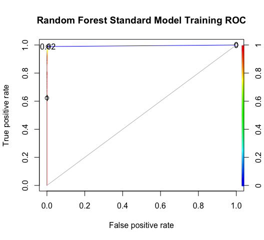

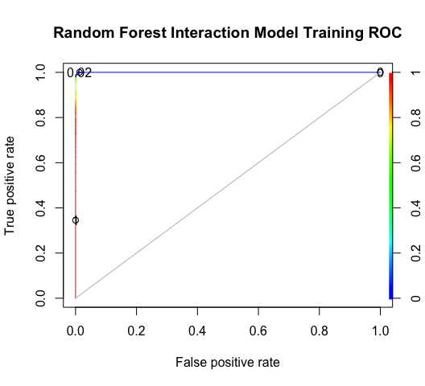

Random Forest Model ROCs - Training Set

#### 4.7.2.2 Holdout Set Performance

The random forest models were then tested for performance on the holdout set.

Both the standard and interaction models returned an accuracy of 99.295%, FNR of 0.005%, and FPR of 74.337%. The AUC of the standard model was 0.98248, and the AUC for the interaction model was 0.98615. Neither of these models performed as well with the holdout set as they did with the training set. This indicated the training set may be over trained or could be a result of the training set not being a good representation of all the data points as a whole.

```r
rf.cm <- cm(rf.fit, rf.thres)
rf.cm
```

```
#> Confusion Matrix and Statistics
#>
#>           Reference
#> Prediction      No     Yes
#>        No  1989597   14069
#>        Yes     100    4857
#>
#>                Accuracy : 0.9929
#>                  95% CI : (0.9928, 0.9931)
#>     No Information Rate : 0.9906
#>     P-Value [Acc > NIR] : < 2.2e-16
#>
#>                   Kappa : 0.4044
#>
#>  Mcnemar's Test P-Value : < 2.2e-16
#>
#>             Sensitivity : 0.9999
#>             Specificity : 0.2566
#>          Pos Pred Value : 0.9930
#>          Neg Pred Value : 0.9798
#>              Prevalence : 0.9906
#>          Detection Rate : 0.9905
#>    Detection Prevalence : 0.9975
#>       Balanced Accuracy : 0.6283
#>
#>        'Positive' Class : No
#>
```

```r
rf.cm.i <- cm(rf.fit, rf.thres)
rf.cm.i
```

```
#> Confusion Matrix and Statistics
#>
#>           Reference
#> Prediction      No     Yes
#>        No  1989597   14069
#>        Yes     100    4857
#>
#>                Accuracy : 0.9929
#>                  95% CI : (0.9928, 0.9931)
#>     No Information Rate : 0.9906
#>     P-Value [Acc > NIR] : < 2.2e-16
#>
#>                   Kappa : 0.4044
#>
#>  Mcnemar's Test P-Value : < 2.2e-16
#>
#>             Sensitivity : 0.9999
#>             Specificity : 0.2566
#>          Pos Pred Value : 0.9930
#>          Neg Pred Value : 0.9798
#>              Prevalence : 0.9906
#>          Detection Rate : 0.9905
#>    Detection Prevalence : 0.9975
#>       Balanced Accuracy : 0.6283
#>
#>        'Positive' Class : No
#>
```

```r
rf.holdout <- holdoutperf(rf.fit, "Random Forest Standard Model Holdout ROC",
                          rf.thres)
rf.holdout.i <- holdoutperf(rf.fit.i,
                            "Random Forest Standard Model Holdout ROC",
                            rf.thres.i)

# AUC
rf.holdout
```

```
#> [1] 0.9824808
```

```r
rf.holdout.i
```

```
#> [1] 0.9861499
```

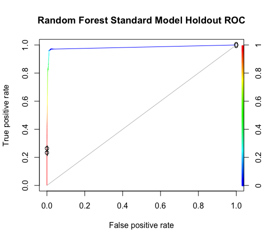

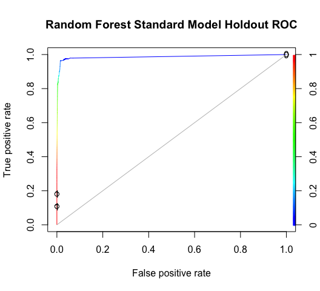

Random Forest Model ROCs - Holdout Set

## 4.8 SVM (Support Vector Machines)

The last method used to generate models was support vector machines (SVM). A radial kernel was selected because the shape of the divide between the blue tarp and non-blue tarp pixels during EDA did not appear to have a perfectly linear relationship nor a very abstract divide. Further evidence for this when the LDA and QDA models were run. The LDA model did not perform well with this data set and though the QDA model has not been the strongest performing of all generated models, it was preferred over the LDA model.

SVM models need to be pre-processed and scaled prior to model training. The features in this data set were already on the same scale of 0 to 255 as it is all the RGB makeup of a pixel and therefore no scaling was completed when generating these models.

Radial SVM models require a `cost` and `sigma` value for training. These parameters were set as an exponential range for model tuning.

```r
cost <- 10^seq(0, 6, by = 0.25)
sigma <- 10^seq(-1, 1, by = 0.5)
```

### 4.8.1 Model Training

```r
svm.fit <- model(Bluetarp ~ ., 'svmRadial', data.frame(C = cost, sigma = sigma))
svm.fit$finalModel
```

```
#> Support Vector Machine object of class "ksvm"
#>
#> SV type: C-svc  (classification)
#>  parameter : cost C = 177.827941003892
#>
#> Gaussian Radial Basis kernel function.
#>  Hyperparameter : sigma =  10
#>
#> Number of Support Vectors : 388
#>
#> Objective Function Value : -53027.19
#> Training error : 0.002135
#> Probability model included.
```

```r
svm.fit
```

```
#> Support Vector Machines with Radial Basis Function Kernel
#>
#> 63241 samples
#>     3 predictor
#>     2 classes: 'No', 'Yes'
#>
#> No pre-processing
#> Resampling: Cross-Validated (10 fold)
#> Summary of sample sizes: 31621, 31621, 31621, 31621, 31621, 31621, ...
#> Resampling results across tuning parameters:
#>
#>   C             sigma       Accuracy   Kappa
#>   1.000000e+00   0.1000000  0.9956894  0.9298848
#>   1.778279e+00   0.3162278  0.9958634  0.9328255
#>   3.162278e+00   1.0000000  0.9964295  0.9417917
#>   5.623413e+00   3.1622777  0.9969007  0.9493716
#>   1.000000e+01  10.0000000  0.9970810  0.9522220
#>   1.778279e+01   0.1000000  0.9960658  0.9357899
#>   3.162278e+01   0.3162278  0.9965560  0.9438990
#>   5.623413e+01   1.0000000  0.9969197  0.9498468
#>   1.000000e+02   3.1622777  0.9971379  0.9535595
#>   1.778279e+02  10.0000000  0.9971853  0.9543738
#>   3.162278e+02   0.1000000  0.9963852  0.9410296
#>   5.623413e+02   0.3162278  0.9968501  0.9486131
#>   1.000000e+03   1.0000000  0.9971157  0.9529743
#>   1.778279e+03   3.1622777  0.9971094  0.9531875
#>   3.162278e+03  10.0000000  0.9966983  0.9467836
#>   5.623413e+03   0.1000000  0.9968438  0.9485794
#>   1.000000e+04   0.3162278  0.9970019  0.9510959
#>   1.778279e+04   1.0000000  0.9971664  0.9537714
#>   3.162278e+04   3.1622777  0.9970999  0.9528619
#>   5.623413e+04  10.0000000  0.9962271  0.9389678
#>   1.000000e+05   0.1000000  0.9969734  0.9505682
#>   1.778279e+05   0.3162278  0.9971379  0.9532946
#>   3.162278e+05   1.0000000  0.9963346  0.9382800
#>   5.623413e+05   3.1622777  0.9954206  0.9217498
#>   1.000000e+06  10.0000000  0.9921147  0.8822285
#>
#> Accuracy was used to select the optimal model using the largest value.
#> The final values used for the model were sigma = 10 and C = 177.8279.
```

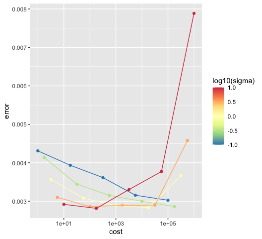

SVM Standard Model Parameter Selection

```r
svm.fit.params <- data.frame(
  cost = svm.fit$results$C,
  sigma = svm.fit$results$sigma,
  error = 1 - svm.fit$results$Accuracy
)
ggplot(svm.fit.params, aes(x = cost, y = error,
                           group = sigma, color = log10(sigma))) +
  geom_point() +
  geom_line() +
  scale_x_log10() +
  scale_colour_distiller(palette = "Spectral")
```

```r
svm.fit.i <- model(Bluetarp ~ . + Green:Blue, 'svmRadial',
                   data.frame(C = cost, sigma = sigma))
svm.fit.i$finalModel
```

```
#> Support Vector Machine object of class "ksvm"
#>
#> SV type: C-svc  (classification)
#>  parameter : cost C = 100
#>
#> Gaussian Radial Basis kernel function.
#>  Hyperparameter : sigma =  3.16227766016838
#>
#> Number of Support Vectors : 422
#>
#> Objective Function Value : -35676.24
#> Training error : 0.002356
#> Probability model included.
```

```r
svm.fit.i
```

```
#> Support Vector Machines with Radial Basis Function Kernel
#>
#> 63241 samples
#>     3 predictor
#>     2 classes: 'No', 'Yes'
#>
#> No pre-processing
#> Resampling: Cross-Validated (10 fold)
#> Summary of sample sizes: 31621, 31621, 31621, 31621, 31621, 31621, ...
#> Resampling results across tuning parameters:
#>
#>   C             sigma       Accuracy   Kappa
#>   1.000000e+00   0.1000000  0.9956831  0.9299323
#>   1.778279e+00   0.3162278  0.9959330  0.9339641
#>   3.162278e+00   1.0000000  0.9964611  0.9422391
#>   5.623413e+00   3.1622777  0.9968849  0.9490271
#>   1.000000e+01  10.0000000  0.9970557  0.9518129
#>   1.778279e+01   0.1000000  0.9960468  0.9354903
#>   3.162278e+01   0.3162278  0.9965180  0.9432382
#>   5.623413e+01   1.0000000  0.9969639  0.9506010
#>   1.000000e+02   3.1622777  0.9971284  0.9534358
#>   1.778279e+02  10.0000000  0.9970715  0.9523973
#>   3.162278e+02   0.1000000  0.9965117  0.9430566
#>   5.623413e+02   0.3162278  0.9968912  0.9493034
#>   1.000000e+03   1.0000000  0.9971189  0.9530447
#>   1.778279e+03   3.1622777  0.9971126  0.9532773
#>   3.162278e+03  10.0000000  0.9965433  0.9441855
#>   5.623413e+03   0.1000000  0.9968406  0.9484262
#>   1.000000e+04   0.3162278  0.9970051  0.9510731
#>   1.778279e+04   1.0000000  0.9970873  0.9523678
#>   3.162278e+04   3.1622777  0.9969924  0.9512624
#>   5.623413e+04  10.0000000  0.9961765  0.9383233
#>   1.000000e+05   0.1000000  0.9969766  0.9505779
#>   1.778279e+05   0.3162278  0.9970968  0.9525215
#>   3.162278e+05   1.0000000  0.9964390  0.9405047
#>   5.623413e+05   3.1622777  0.9961480  0.9362878
#>   1.000000e+06  10.0000000  0.9917046  0.8761002
#>
#> Accuracy was used to select the optimal model using the largest value.
#> The final values used for the model were sigma = 3.162278 and C = 100.
```

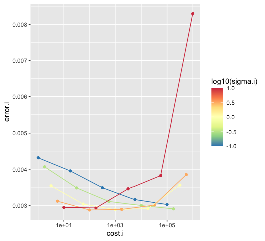

SVM Interaction Model Parameter Selection

```r
svm.fit.i.params <- data.frame(
  cost.i = svm.fit.i$results$C,
  sigma.i = svm.fit.i$results$sigma,
  error.i = 1 - svm.fit.i$results$Accuracy
)
ggplot(svm.fit.i.params, aes(x = cost.i, y = error.i,
                             group = sigma.i, color = log10(sigma.i))) +
  geom_point() +
  geom_line() +
  scale_x_log10() +
  scale_colour_distiller(palette = "Spectral")
```

### 4.8.2 Model Performance

#### 4.8.2.1 Training Set Performance

After determining the best parameter values, the best probability threshold was determined.

The optimal threshold for the SVM standard model was 0.55, resulting in an accuracy of 99.719%, FNR of 0.140%, and FPR of 4.530%. The calculated AUC was 0.99921. This model outperformed the KNN standard model, the previous “front runner”, with the training performance.

The SVM interaction model performed best at a threshold of 0.60. At this threshold, the model returned a test accuracy of 99.713%, FNR of 0.158%, and FPR of 4.194%. This model performed just under the SVM standard model and is the second best of the bunch in terms of the training performance.

```r
svm.thres <- threshold(svm.fit)
svm.thres.i <- threshold(svm.fit.i)

# determining best threshold row for highlighting
svm.best <- svm.thres %>%
  dplyr::select("prob_threshold", "Accuracy", "FNR", "FPR", "Dist", "F1") %>%
  slice(which.max(Accuracy)) %>%
  slice(which.min(FNR))
svm.bestrow <- which(svm.thres$FNR == svm.best$FNR)

svm.best.i <- svm.thres.i %>%
  dplyr::select("prob_threshold", "Accuracy", "FNR", "FPR", "Dist", "F1") %>%
  slice(which.max(Accuracy)) %>%
  slice(which.min(FNR))
svm.bestrow.i <- which(svm.thres.i$FNR == svm.best.i$FNR)

# table of threshold values
svm.thres %>%
    dplyr::select("prob_threshold", "Accuracy", "FNR", "FPR", "Dist", "F1") %>%
    knitr::kable(digits = 5,
                 caption = "SVM Regression Standard Model
                 Probability Threshold Table") %>%
    kableExtra::kable_styling(full_width = FALSE) %>%
    kableExtra::row_spec(row = svm.bestrow, bold = TRUE,
                         background = '#D3D3D3') %>%
    kable_styling(latex_options = "HOLD_position")
```

SVM Regression Standard Model Probability Threshold Table

| prob_threshold | Accuracy | FNR | FPR | Dist | F1 |
| --- | --- | --- | --- | --- | --- |
| 0.05 | 0.99195 | 0.00044 | 0.23838 | 0.23838 | 0.99586 |
| 0.10 | 0.99590 | 0.00071 | 0.10692 | 0.10693 | 0.99788 |
| 0.15 | 0.99659 | 0.00084 | 0.08121 | 0.08121 | 0.99824 |
| 0.20 | 0.99682 | 0.00096 | 0.07033 | 0.07033 | 0.99836 |
| 0.25 | 0.99690 | 0.00108 | 0.06419 | 0.06420 | 0.99840 |
| 0.30 | 0.99699 | 0.00114 | 0.05964 | 0.05966 | 0.99845 |
| 0.35 | 0.99707 | 0.00118 | 0.05598 | 0.05600 | 0.99848 |
| 0.40 | 0.99712 | 0.00124 | 0.05262 | 0.05264 | 0.99851 |
| 0.45 | 0.99716 | 0.00129 | 0.04975 | 0.04977 | 0.99853 |
| 0.50 | 0.99719 | 0.00134 | 0.04748 | 0.04750 | 0.99855 |
| 0.55 | 0.99719 | 0.00140 | 0.04530 | 0.04532 | 0.99855 |
| 0.60 | 0.99719 | 0.00148 | 0.04303 | 0.04305 | 0.99855 |
| 0.65 | 0.99719 | 0.00153 | 0.04154 | 0.04157 | 0.99855 |
| 0.70 | 0.99718 | 0.00162 | 0.03937 | 0.03940 | 0.99854 |
| 0.75 | 0.99713 | 0.00172 | 0.03778 | 0.03782 | 0.99852 |
| 0.80 | 0.99709 | 0.00182 | 0.03591 | 0.03595 | 0.99850 |
| 0.85 | 0.99704 | 0.00194 | 0.03373 | 0.03379 | 0.99847 |
| 0.90 | 0.99696 | 0.00213 | 0.03056 | 0.03064 | 0.99843 |

```r
svm.thres.i %>%
    dplyr::select("prob_threshold", "Accuracy", "FNR", "FPR", "Dist", "F1") %>%
    knitr::kable(digits = 5,
                 caption = "SVM Interaction Model
                 Probability Threshold Table") %>%
    kableExtra::kable_styling(full_width = FALSE) %>%
    kableExtra::row_spec(row = svm.bestrow.i, bold = TRUE,
                         background = '#D3D3D3') %>%
    kable_styling(latex_options = "HOLD_position")
```

SVM Interaction Model Probability Threshold Table

| prob_threshold | Accuracy | FNR | FPR | Dist | F1 |
| --- | --- | --- | --- | --- | --- |
| 0.05 | 0.99234 | 0.00022 | 0.23314 | 0.23314 | 0.99606 |
| 0.10 | 0.99549 | 0.00041 | 0.12839 | 0.12839 | 0.99768 |
| 0.15 | 0.99641 | 0.00064 | 0.09298 | 0.09298 | 0.99815 |
| 0.20 | 0.99667 | 0.00077 | 0.08081 | 0.08082 | 0.99828 |
| 0.25 | 0.99681 | 0.00088 | 0.07329 | 0.07330 | 0.99835 |
| 0.30 | 0.99692 | 0.00099 | 0.06637 | 0.06638 | 0.99841 |
| 0.35 | 0.99701 | 0.00106 | 0.06142 | 0.06143 | 0.99846 |
| 0.40 | 0.99709 | 0.00116 | 0.05598 | 0.05600 | 0.99850 |
| 0.45 | 0.99711 | 0.00128 | 0.05173 | 0.05175 | 0.99851 |
| 0.50 | 0.99713 | 0.00136 | 0.04857 | 0.04859 | 0.99852 |
| 0.55 | 0.99713 | 0.00146 | 0.04550 | 0.04552 | 0.99852 |
| 0.60 | 0.99713 | 0.00158 | 0.04194 | 0.04197 | 0.99852 |
| 0.65 | 0.99709 | 0.00172 | 0.03907 | 0.03911 | 0.99850 |
| 0.70 | 0.99706 | 0.00189 | 0.03501 | 0.03507 | 0.99848 |
| 0.75 | 0.99705 | 0.00201 | 0.03165 | 0.03172 | 0.99847 |
| 0.80 | 0.99697 | 0.00220 | 0.02819 | 0.02828 | 0.99843 |
| 0.85 | 0.99680 | 0.00245 | 0.02591 | 0.02604 | 0.99834 |
| 0.90 | 0.99651 | 0.00286 | 0.02255 | 0.02274 | 0.99819 |

```r
# ROC
svm.ROC <- ROC(svm.fit, "SVM Standard Model Training ROC", svm.thres)
```

```
#> Confusion Matrix and Statistics
#>
#>           Reference
#> Prediction    No   Yes
#>        No  61219  1145
#>        Yes     0   877
#>
#>                Accuracy : 0.9819
#>                  95% CI : (0.9808, 0.9829)
#>     No Information Rate : 0.968
#>     P-Value [Acc > NIR] : < 2.2e-16
#>
#>                   Kappa : 0.5972
#>
#>  Mcnemar's Test P-Value : < 2.2e-16
#>
#>             Sensitivity : 1.0000
#>             Specificity : 0.4337
#>          Pos Pred Value : 0.9816
#>          Neg Pred Value : 1.0000
#>              Prevalence : 0.9680
#>          Detection Rate : 0.9680
#>    Detection Prevalence : 0.9861
#>       Balanced Accuracy : 0.7169
#>
#>        'Positive' Class : No
#>
```

```r
svm.ROC.i <- ROC(svm.fit.i, "SVM Interaction Model Training ROC", svm.thres.i)
```

```
#> Confusion Matrix and Statistics
#>
#>           Reference
#> Prediction    No   Yes
#>        No  61219  1046
#>        Yes     0   976
#>
#>                Accuracy : 0.9835
#>                  95% CI : (0.9824, 0.9844)
#>     No Information Rate : 0.968
#>     P-Value [Acc > NIR] : < 2.2e-16
#>
#>                   Kappa : 0.6437
#>
#>  Mcnemar's Test P-Value : < 2.2e-16
#>
#>             Sensitivity : 1.0000
#>             Specificity : 0.4827
#>          Pos Pred Value : 0.9832
#>          Neg Pred Value : 1.0000
#>              Prevalence : 0.9680
#>          Detection Rate : 0.9680
#>    Detection Prevalence : 0.9846
#>       Balanced Accuracy : 0.7413
#>
#>        'Positive' Class : No
#>
```

```r
# AUC
svm.ROC
```

```
#> [1] 0.9992072
```

```r
svm.ROC.i
```

```
#> [1] 0.9997867
```

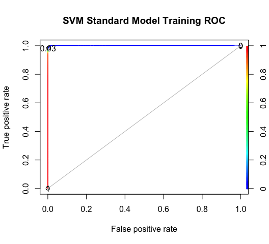

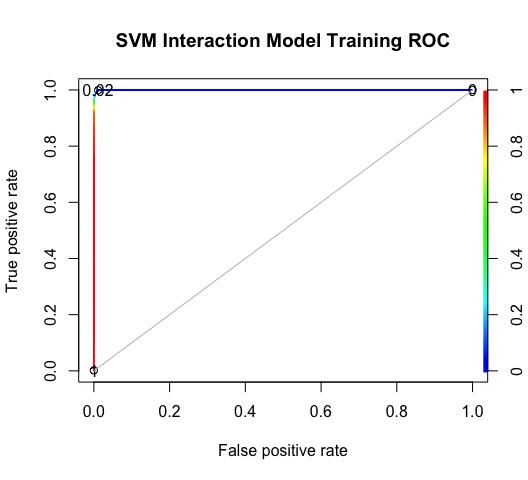

SVM Model ROCs - Training Set

#### 4.8.2.2 Holdout Set Performance

Finally, the holdout set was used to test both the SVM standard and interaction models.

The standard model, at the 0.55 probability threshold, returned an accuracy of 99.004%, FNR of 0.229%, and FPR of 81.607%. The AUC was 0.91245. Sadly, this model did not perform as well with the holdout set, indicating the trained model may be over trained.

The extremely high FPR rate returned from the holdout performance test with both the standard and interaction models was very disappointing. This suggested that the SVM algorithms may not be the best choice in the Haiti disaster relief efforts with the holdout set.

```r
svm.cm <- cm(svm.fit, svm.thres)
svm.cm
```

```
#> Confusion Matrix and Statistics
#>
#>           Reference
#> Prediction      No     Yes
#>        No  1985133   15445
#>        Yes    4564    3481
#>
#>                Accuracy : 0.99
#>                  95% CI : (0.9899, 0.9902)
#>     No Information Rate : 0.9906
#>     P-Value [Acc > NIR] : 1
#>
#>                   Kappa : 0.2539
#>
#>  Mcnemar's Test P-Value : <2e-16
#>
#>             Sensitivity : 0.9977
#>             Specificity : 0.1839
#>          Pos Pred Value : 0.9923
#>          Neg Pred Value : 0.4327
#>              Prevalence : 0.9906
#>          Detection Rate : 0.9883
#>    Detection Prevalence : 0.9960
#>       Balanced Accuracy : 0.5908
#>
#>        'Positive' Class : No
#>
```

```r
svm.cm.i <- cm(svm.fit, svm.thres)
svm.cm.i
```

```
#> Confusion Matrix and Statistics
#>
#>           Reference
#> Prediction      No     Yes
#>        No  1985133   15445
#>        Yes    4564    3481
#>
#>                Accuracy : 0.99
#>                  95% CI : (0.9899, 0.9902)
#>     No Information Rate : 0.9906
#>     P-Value [Acc > NIR] : 1
#>
#>                   Kappa : 0.2539
#>
#>  Mcnemar's Test P-Value : <2e-16
#>
#>             Sensitivity : 0.9977
#>             Specificity : 0.1839
#>          Pos Pred Value : 0.9923
#>          Neg Pred Value : 0.4327
#>              Prevalence : 0.9906
#>          Detection Rate : 0.9883
#>    Detection Prevalence : 0.9960
#>       Balanced Accuracy : 0.5908
#>
#>        'Positive' Class : No
#>
```

```r
# ROC
svm.holdout <- holdoutperf(svm.fit, "SVM Standard Model Holdout ROC", svm.thres)
svm.holdout.i <- holdoutperf(svm.fit.i, "SVM Interaction Model Holdout ROC",
                             svm.thres.i)

# AUC
svm.holdout
```

```
#> [1] 0.9124492
```

```r
svm.holdout.i
```

```
#> [1] 0.932906
```

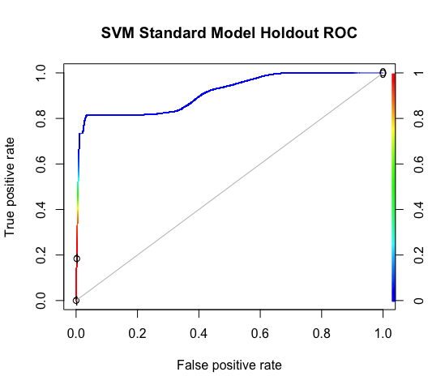

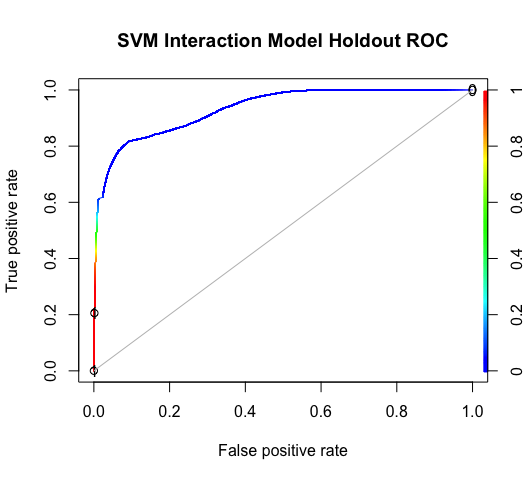

SVM Model ROCs - Holdout Set

## 4.9 Model Performance Comparisons and Results

After completing the initial model creation and computation of performance metrics were completed, the different algorithm performances were compared. A table was created to most easily digest the information and determine the best performing model to locate blue tarps.

Table 20 represents the thresholds and parameters associated with the best model for that method. Table 21 displays the model performance, highlighting the model that performed best with the training data. Both Table 20 and Table 21 were validated using 10-Fold Cross-Validation.

Table 22 represents the model performance with the holdout set, highlighting the model with the best test metrics.

```r
params <- data.frame(matrix(nrow = 14, ncol = 3))

params.names <- c("Model", "Parameter", "prob_threshold")

colnames(params) <- params.names

model.names <- c("Logistic Regression Standard Model",
                 "Logistic Regression Interaction Model",
                 "LDA Standard Model",
                 "LDA Ineration Model",
                 "QDA Standard Model",
                 "QDA Interaction Model",
                 "KNN Standard Model",
                 "KNN Interaction Model",
                 "Ridge Regression Standard Model",
                 "Ridge Regression Interaction Model",
                 "Random Forest Standard Model",
                 "Random Forest Interaction Model",
                 "SVM Standard Model, Radial Kernel",
                 "SVM Interaction Model, Radial Kernel")

params["Model"] <- model.names

# pulling individual model threshold and parameter stats
lr.params <- lr.thres %>%
  slice_max(Accuracy) %>%
  slice_min(FNR) %>%
  dplyr::select("parameter", "prob_threshold") %>%
  mutate("Model" = "Logistic Regression Standard Model") %>%
  mutate(across(where(is.numeric), ~ round(., 5)))

lr.i.params <- lr.thres.i %>%
  slice_max(Accuracy) %>%
  slice_min(FNR) %>%
  dplyr::select("parameter", "prob_threshold") %>%
  mutate("Model" = "Logistic Regression Interaction Model") %>%
  mutate(across(where(is.numeric), ~ round(., 5)))

lda.params <- lda.thres %>%
  slice_max(Accuracy) %>%
  slice_min(FNR) %>%
  dplyr::select("parameter", "prob_threshold") %>%
  mutate("Model" = "LDA Standard Model") %>%
  mutate(across(where(is.numeric), ~ round(., 5)))

lda.i.params <- lda.thres.i %>%
  slice_max(Accuracy) %>%
  slice_min(FNR) %>%
  dplyr::select("parameter", "prob_threshold") %>%
  mutate("Model" = "LDA Interaction Model") %>%
  mutate(across(where(is.numeric), ~ round(., 5)))

qda.params <- qda.thres %>%
  slice_max(Accuracy) %>%
  slice_min(FNR) %>%
  dplyr::select("parameter", "prob_threshold") %>%
  mutate("Model" = "QDA Standard Model") %>%
  mutate(across(where(is.numeric), ~ round(., 5)))

qda.i.params <- qda.thres.i %>%
  slice_max(Accuracy) %>%
  slice_min(FNR) %>%
  dplyr::select("parameter", "prob_threshold") %>%
  mutate("Model" = "QDA Interaction Model") %>%
  mutate(across(where(is.numeric), ~ round(., 5)))

knn.params <- knn.thres %>%
  slice_max(Accuracy) %>%
  slice_min(FNR) %>%
  slice_max(prob_threshold) %>%
  dplyr::select("k", "prob_threshold") %>%
  mutate("Model" = "KNN Standard Model") %>%
  rename("parameter" = "k") %>%
  mutate(across(where(is.numeric), ~ round(., 5)))
knn.params$parameter <- as.character(knn.params$parameter)
knn.params['parameter'] <- as.character(knn.params['parameter'])
knn.params['parameter'] <-  str_c('k = ', knn.params['parameter'])

knn.i.params <- knn.thres.i %>%
  slice_max(Accuracy) %>%
  slice_min(FNR) %>%
  slice_max(prob_threshold) %>%
  dplyr::select("k", "prob_threshold") %>%
  mutate("Model" = "KNN Interaction Model") %>%
  rename("parameter" = "k") %>%
  mutate(across(where(is.numeric), ~ round(., 5)))
knn.i.params$parameter <- as.character(knn.i.params$parameter)
knn.i.params['parameter'] <- as.character(knn.i.params['parameter'])
knn.i.params['parameter'] <-  str_c('k = ', knn.i.params['parameter'])

ridge.params <- ridge.thres %>%
  slice_max(Accuracy) %>%
  slice_min(FNR) %>%
  dplyr::select("lambda", "prob_threshold") %>%
  mutate("Model" = "Ridge Regression Standard Model") %>%
  rename("parameter" = "lambda") %>%
  mutate(across(where(is.numeric), ~ round(., 5)))
ridge.params$parameter <- as.character(ridge.params$parameter)
ridge.params['parameter'] <- as.character(ridge.params['parameter'])
ridge.params['parameter'] <-  str_c('lambda = ', ridge.params['parameter'])

ridge.i.params <- ridge.thres.i %>%
  slice_max(Accuracy) %>%
  slice_min(FNR) %>%
  dplyr::select("lambda", "prob_threshold") %>%
  mutate("Model" = "Ridge Regression Interaction Model") %>%
  rename("parameter" = "lambda") %>%
  mutate(across(where(is.numeric), ~ round(., 5)))
ridge.i.params$parameter <- as.character(ridge.i.params$parameter)
ridge.i.params['parameter'] <- as.character(ridge.i.params['parameter'])
ridge.i.params['parameter'] <-  str_c('lambda = ', ridge.i.params['parameter'])

rf.params2 <- rf.thres %>%
  slice_max(Accuracy) %>%
  slice_min(FNR) %>%
  dplyr::select("mtry", "prob_threshold") %>%
  mutate("Model" = "Random Forest Standard Model") %>%
  rename("parameter" = "mtry") %>%
  mutate(across(where(is.numeric), ~ round(., 5)))
rf.params2$parameter <- as.character(rf.params2$parameter)
rf.params2['parameter'] <- as.character(rf.params2['parameter'])
rf.params2['parameter'] <-  str_c('mtry = ', rf.params2['parameter'],
                                  ', ntrees = ', rf.params['ntree'])
rf.i.params2 <- rf.thres.i %>%
  slice_max(Accuracy) %>%
  slice_min(FNR) %>%
  dplyr::select("mtry", "prob_threshold") %>%
  mutate("Model" = "Random Forest Interaction Model") %>%
  rename("parameter" = "mtry") %>%
  mutate(across(where(is.numeric), ~ round(., 5)))
rf.i.params2$parameter <- as.character(rf.i.params2$parameter)
rf.i.params2['parameter'] <- as.character(rf.i.params2['parameter'])
rf.i.params2['parameter'] <-  str_c('mtry = ', rf.i.params2['parameter'],
                                  ', ntrees = ', rf.i.params['ntree'])
svm.params <- svm.thres %>%
  slice_max(Accuracy) %>%
  slice_min(FNR) %>%
  dplyr::select("C", "prob_threshold") %>%
  mutate("Model" = "SVM Standard Model, Radial Kernel") %>%
  rename("parameter" = "C") %>%
  mutate(across(where(is.numeric), ~ round(., 5)))
svm.params$parameter <- as.character(svm.params$parameter)
svm.params['parameter'] <- as.character(svm.params['parameter'])
svm.params['parameter'] <-  str_c('C = ', svm.params['parameter'],
                                  ', sigma = ', svm.fit$bestTune['sigma'])

svm.i.params <- svm.thres.i %>%
  slice_max(Accuracy) %>%
  slice_min(FNR) %>%
  dplyr::select("C", "prob_threshold") %>%
  mutate("Model" = "SVM Interaction Model, Radial Kernel") %>%
  rename("parameter" = "C") %>%
  mutate(across(where(is.numeric), ~ round(., 5)))
svm.fit.i$bestTune['sigma'] <- svm.fit.i$bestTune['sigma'] %>%
  mutate(across(where(is.numeric), ~ round(., 5)))
svm.i.params$parameter <- as.character(svm.i.params$parameter)
svm.i.params['parameter'] <- as.character(svm.i.params['parameter'])
svm.i.params['parameter'] <-  str_c('C = ', svm.i.params['parameter'],
                                  ', sigma = ', svm.fit.i$bestTune['sigma'])

# merging threshold rows into comparison data frame
params <- bind_rows(lr.params, lr.i.params,
                        lda.params, lda.i.params,
                        qda.params, qda.i.params,
                        knn.params, knn.i.params,
                        ridge.params, ridge.i.params,
                        rf.params2, rf.i.params2,
                        svm.params, svm.i.params) %>%
  na_if(., "none") %>%
  rename("Parameter" = "parameter", "Threshold" = "prob_threshold") %>%
  relocate("Model","Threshold")

# generating table
params %>%
  knitr::kable(caption = "Model Parameter and Threshold Table -
               10x Cross-Validation") %>%
  kableExtra::kable_styling(full_width = FALSE) %>%
  kable_styling(latex_options = "HOLD_position", position = "center")
```

Model Parameter and Threshold Table - 10x Cross-Validation

| Model | Threshold | Parameter |
| --- | --- | --- |
| Logistic Regression Standard Model | 0.75 | NA |
| Logistic Regression Interaction Model | 0.75 | NA |
| LDA Standard Model | 0.15 | NA |
| LDA Interaction Model | 0.70 | NA |
| QDA Standard Model | 0.75 | NA |
| QDA Interaction Model | 0.05 | NA |
| KNN Standard Model | 0.40 | k = 5 |
| KNN Interaction Model | 0.65 | k = 1 |
| Ridge Regression Standard Model | 0.75 | lambda = 0.00398 |
| Ridge Regression Interaction Model | 0.70 | lambda = 0.00398 |
| Random Forest Standard Model | 0.50 | mtry = 2, ntrees = 41 |
| Random Forest Interaction Model | 0.60 | mtry = 1, ntrees = 472 |
| SVM Standard Model, Radial Kernel | 0.55 | C = 177.82794, sigma = 10 |
| SVM Interaction Model, Radial Kernel | 0.60 | C = 100, sigma = 3.16228 |

```r
# creating new data frame and naming columns
comparison <- data.frame(matrix(nrow = 14, ncol = 6))

comparison.names <- c("Model", "Accuracy", "FNR", "FPR", "Dist", "F1")

colnames(comparison) <- comparison.names
comparison["Model"] <- model.names


# pulling individual model stats from generated thresholds
lr.stats <- lr.thres %>%
  slice_max(Accuracy) %>%
  slice_min(FNR) %>%
  dplyr::select("Accuracy", "FNR", "FPR", "Dist", "F1") %>%
  mutate("Model" = "Logistic Regression Standard Model") %>%
  mutate(across(where(is.numeric), ~ round(., 5)))

lr.i.stats <- lr.thres.i %>%
  slice_max(Accuracy) %>%
  slice_min(FNR) %>%
  dplyr::select("Accuracy", "FNR", "FPR", "Dist", "F1") %>%
  mutate("Model" = "Logistic Regression Interaction Model") %>%
  mutate(across(where(is.numeric), ~ round(., 5)))

lda.stats <- lda.thres %>%
  slice_max(Accuracy) %>%
  slice_min(FNR) %>%
  dplyr::select("Accuracy", "FNR", "FPR", "Dist", "F1") %>%
  mutate("Model" = "LDA Standard Model") %>%
  mutate(across(where(is.numeric), ~ round(., 5)))

lda.i.stats <- lda.thres.i %>%
  slice_max(Accuracy) %>%
  slice_min(FNR) %>%
  dplyr::select("Accuracy", "FNR", "FPR", "Dist", "F1") %>%
  mutate("Model" = "LDA Interaction Model") %>%
  mutate(across(where(is.numeric), ~ round(., 5)))

qda.stats <- qda.thres %>%
  slice_max(Accuracy) %>%
  slice_min(FNR) %>%
  dplyr::select("Accuracy", "FNR", "FPR", "Dist", "F1") %>%
  mutate("Model" = "QDA Standard Model") %>%
  mutate(across(where(is.numeric), ~ round(., 5)))

qda.i.stats <- qda.thres.i %>%
  slice_max(Accuracy) %>%
  slice_min(FNR) %>%
  dplyr::select("Accuracy", "FNR", "FPR", "Dist", "F1") %>%
  mutate("Model" = "QDA Interaction Model") %>%
  mutate(across(where(is.numeric), ~ round(., 5)))

knn.stats <- knn.thres %>%
  slice_max(Accuracy) %>%
  slice_min(FNR) %>%
  slice_max(prob_threshold) %>%
  dplyr::select("Accuracy", "FNR", "FPR", "Dist", "F1") %>%
  mutate("Model" = "KNN Standard Model") %>%
  mutate(across(where(is.numeric), ~ round(., 5)))

knn.i.stats <- knn.thres.i %>%
  slice_max(Accuracy) %>%
  slice_min(FNR) %>%
  slice_max(prob_threshold) %>%
  dplyr::select("Accuracy", "FNR", "FPR", "Dist", "F1") %>%
  mutate("Model" = "KNN Interaction Model") %>%
  mutate(across(where(is.numeric), ~ round(., 5)))

ridge.stats <- ridge.thres %>%
  slice_max(Accuracy) %>%
  slice_min(FNR) %>%
  dplyr::select("Accuracy", "FNR", "FPR", "Dist", "F1") %>%
  mutate("Model" = "Ridge Regression Standard Model") %>%
  mutate(across(where(is.numeric), ~ round(., 5)))

ridge.i.stats <- ridge.thres.i %>%
  slice_max(Accuracy) %>%
  slice_min(FNR) %>%
  dplyr::select("Accuracy", "FNR", "FPR", "Dist", "F1") %>%
  mutate("Model" = "Ridge Regression Interaction Model") %>%
  mutate(across(where(is.numeric), ~ round(., 5)))

rf.stats <- rf.thres %>%
  slice_max(Accuracy) %>%
  slice_min(FNR) %>%
  dplyr::select("Accuracy", "FNR", "FPR", "Dist", "F1") %>%
  mutate("Model" = "Random Forest Standard Model") %>%
  mutate(across(where(is.numeric), ~ round(., 5)))

rf.i.stats <- rf.thres.i %>%
  slice_max(Accuracy) %>%
  slice_min(FNR) %>%
  dplyr::select("Accuracy", "FNR", "FPR", "Dist", "F1") %>%
  mutate("Model" = "Random Forest Interaction Model") %>%
  mutate(across(where(is.numeric), ~ round(., 5)))

svm.stats <- svm.thres %>%
  slice_max(Accuracy) %>%
  slice_min(FNR) %>%
  dplyr::select("Accuracy", "FNR", "FPR", "Dist", "F1") %>%
  mutate("Model" = "SVM Standard Model, Radial Kernel") %>%
  mutate(across(where(is.numeric), ~ round(., 5)))

svm.i.stats <- svm.thres.i %>%
  slice_max(Accuracy) %>%
  slice_min(FNR) %>%
  dplyr::select("Accuracy", "FNR", "FPR", "Dist", "F1") %>%
  mutate("Model" = "SVM Interaction Model, Radial Kernel") %>%
  mutate(across(where(is.numeric), ~ round(., 5)))

# AUC list
modelAUCs <- c(lr.ROC, lr.ROC.i,
               lda.ROC, lda.ROC.i,
               qda.ROC, qda.ROC.i,
               knn.ROC, knn.ROC.i,
               ridge.ROC, ridge.ROC.i,
               rf.ROC, rf.ROC.i,
               svm.ROC, svm.ROC.i)

# merging threshold rows into comparison data frame
comparison <- bind_rows(lr.stats, lr.i.stats,
                        lda.stats, lda.i.stats,
                        qda.stats, qda.i.stats,
                        knn.stats, knn.i.stats,
                        ridge.stats, ridge.i.stats,
                        rf.stats, rf.i.stats,
                        svm.stats, svm.i.stats) %>%
  na_if(., "none") %>%
  relocate("Model","Accuracy")

# merging AUCs and rounding values
comparison <- comparison %>%
  mutate(AUC = modelAUCs) %>%
  relocate("AUC", .after = "Accuracy") %>%
  mutate(across(where(is.numeric), ~ round(., 5)))

# best model for highlighting
findbest <- comparison %>%
  slice(which.max(Accuracy)) %>%
  slice(which.min(FNR))
bestmodel <- which(findbest$Model == comparison$Model)

# converting accuracy, FNR, and FPR into strings to make percentages
comparison$Accuracy <- 100* comparison$Accuracy
comparison$Accuracy <- as.character(comparison$Accuracy)
comparison$Accuracy <-  str_c(comparison$Accuracy, '%')

comparison$FNR <- 100* comparison$FNR
comparison$FNR <- as.character(comparison$FNR)
comparison$FNR <-  str_c(comparison$FNR, '%')

comparison$FPR <- 100* comparison$FPR
comparison$FPR <- as.character(comparison$FPR)
comparison$FPR <-  str_c(comparison$FPR, '%')

# generating table
comparison %>%
  knitr::kable(caption = "Model Statistic Comparison Table -
               10x Cross-Validation") %>%
  kableExtra::kable_styling(full_width = FALSE) %>%
  kableExtra::row_spec(row = bestmodel, bold = TRUE,
                         background = '#D3D3D3') %>%
  kable_styling(latex_options = "HOLD_position", position = "center")
```

Model Statistic Comparison Table - 10x Cross-Validation

| Model | Accuracy | AUC | FNR | FPR | Dist | F1 |
| --- | --- | --- | --- | --- | --- | --- |
| Logistic Regression Standard Model | 99.576% | 0.99851 | 0.172% | 8.032% | 0.08034 | 0.99781 |
| Logistic Regression Interaction Model | 99.6% | 0.99953 | 0.267% | 4.441% | 0.04450 | 0.99793 |
| LDA Standard Model | 98.485% | 0.98888 | 0.767% | 24.174% | 0.24186 | 0.99218 |
| LDA Interaction Model | 99.441% | 0.99525 | 0.134% | 13.442% | 0.13443 | 0.99712 |
| QDA Standard Model | 99.478% | 0.99822 | 0.085% | 13.759% | 0.13759 | 0.99731 |
| QDA Interaction Model | 99.469% | 0.99709 | 0.061% | 14.738% | 0.14738 | 0.99726 |
| KNN Standard Model | 99.701% | 0.99986 | 0.164% | 4.402% | 0.04405 | 0.99845 |
| KNN Interaction Model | 99.232% | 0.99997 | 0.233% | 16.954% | 0.16955 | 0.99604 |
| Ridge Regression Standard Model | 98.623% | 0.98019 | 0.051% | 41.503% | 0.41504 | 0.99294 |
| Ridge Regression Interaction Model | 98.525% | 0.97814 | 0% | 46.133% | 0.46133 | 0.99244 |
| Random Forest Standard Model | 99.685% | 0.99450 | 0.152% | 5.252% | 0.05255 | 0.99837 |
| Random Forest Interaction Model | 99.69% | 0.99994 | 0.184% | 4.115% | 0.04119 | 0.99840 |
| SVM Standard Model, Radial Kernel | 99.719% | 0.99921 | 0.14% | 4.53% | 0.04532 | 0.99855 |
| SVM Interaction Model, Radial Kernel | 99.713% | 0.99979 | 0.158% | 4.194% | 0.04197 | 0.99852 |

```r
comparison.holdout <- data.frame(matrix(nrow = 14, ncol = 5))

holdout.names <- c("Model", "Accuracy", "FNR", "FPR", "F1")

colnames(comparison.holdout) <- holdout.names
comparison.holdout["Model"] <- model.names

# generating values for table
accuracies <- c(lr.cm$overall['Accuracy'],
                lr.cm.i$overall['Accuracy'],
                lda.cm$overall['Accuracy'],
                lda.cm.i$overall['Accuracy'],
                qda.cm$overall['Accuracy'],
                qda.cm.i$overall['Accuracy'],
                knn.cm$overall['Accuracy'],
                knn.cm.i$overall['Accuracy'],
                ridge.cm$overall['Accuracy'],
                ridge.cm.i$overall['Accuracy'],
                rf.cm$overall['Accuracy'],
                rf.cm.i$overall['Accuracy'],
                svm.cm$overall['Accuracy'],
                svm.cm.i$overall['Accuracy'])

fnr <- c(mean(lr.cm$FNR['Sensitivity']),
         mean(lr.cm$FNR['Sensitivity']),
         mean(lda.cm$FNR['Sensitivity']),
         mean(lda.cm.i$FNR['Sensitivity']),
         mean(qda.cm$FNR['Sensitivity']),
         mean(qda.cm.i$FNR['Sensitivity']),
         mean(knn.cm$FNR['Sensitivity']),
         mean(knn.cm.i$FNR['Sensitivity']),
         mean(ridge.cm$FNR['Sensitivity']),
         mean(ridge.cm.i$FNR['Sensitivity']),
         mean(rf.cm$FNR['Sensitivity']),
         mean(rf.cm.i$FNR['Sensitivity']),
         mean(svm.cm$FNR['Sensitivity']),
         mean(svm.cm.i$FNR['Sensitivity']))

fpr <- c(mean(lr.cm$FPR['Specificity']),
         mean(lr.cm.i$FPR['Specificity']),
         mean(lda.cm$FPR['Specificity']),
         mean(lda.cm.i$FPR['Specificity']),
         mean(qda.cm$FPR['Specificity']),
         mean(qda.cm.i$FPR['Specificity']),
         mean(knn.cm$FPR['Specificity']),
         mean(knn.cm.i$FPR['Specificity']),
         mean(ridge.cm$FPR['Specificity']),
         mean(ridge.cm.i$FPR['Specificity']),
         mean(rf.cm$FPR['Specificity']),
         mean(rf.cm.i$FPR['Specificity']),
         mean(svm.cm$FPR['Specificity']),
         mean(svm.cm.i$FPR['Specificity']))

f1 <- c(lr.cm$byClass['F1'],
        lr.cm.i$byClass['F1'],
        lda.cm$byClass['F1'],
        lda.cm.i$byClass['F1'],
        qda.cm$byClass['F1'],
        qda.cm.i$byClass['F1'],
        knn.cm$byClass['F1'],
        knn.cm.i$byClass['F1'],
        ridge.cm$byClass['F1'],
        ridge.cm.i$byClass['F1'],
        rf.cm$byClass['F1'],
        rf.cm.i$byClass['F1'],
        svm.cm$byClass['F1'],
        svm.cm.i$byClass['F1'])

holdoutAUCs <- c(lr.holdout, lr.holdout.i,
               lda.holdout, lda.holdout.i,
               qda.holdout, qda.holdout.i,
               knn.holdout, knn.holdout.i,
               ridge.holdout, ridge.holdout.i,
               rf.holdout, rf.holdout.i,
               svm.holdout, svm.holdout.i)

# merging data vectors into holdout comparison data frame
comparison.holdout <- comparison.holdout %>%
  mutate(Accuracy = accuracies) %>%
  mutate(AUC = holdoutAUCs) %>%
  mutate(FNR = fnr) %>%
  mutate(FPR = fpr) %>%
  mutate(F1 = f1) %>%
  na_if(., "none") %>%
  relocate("Model","Accuracy") %>%
  relocate("AUC", .after = "Accuracy") %>%
  mutate(across(where(is.numeric), ~ round(., 5)))

# best model for highlighting
findbest.holdout <- comparison.holdout %>%
  slice(which.max(Accuracy)) %>%
  slice(which.min(FNR))
best.holdout <- which(findbest.holdout$Model == comparison.holdout$Model)

# converting accuracy, FNR, and FPR into strings to make percentages
comparison.holdout$Accuracy <- 100* comparison.holdout$Accuracy
comparison.holdout$Accuracy <- as.character(comparison.holdout$Accuracy)
comparison.holdout$Accuracy <-  str_c(comparison.holdout$Accuracy, '%')

comparison.holdout$FNR <- 100* comparison.holdout$FNR
comparison.holdout$FNR <- as.character(comparison.holdout$FNR)
comparison.holdout$FNR <-  str_c(comparison.holdout$FNR, '%')

comparison.holdout$FPR <- 100* comparison.holdout$FPR
comparison.holdout$FPR <- as.character(comparison.holdout$FPR)
comparison.holdout$FPR <-  str_c(comparison.holdout$FPR, '%')

# generating table
comparison.holdout %>%
  knitr::kable(caption = "Model Statistic Comparison Table - Holdout Set") %>%
  kableExtra::kable_styling(full_width = FALSE) %>%
  kableExtra::row_spec(row = best.holdout, bold = TRUE,
                         background = '#D3D3D3') %>%
  kable_styling(latex_options = "HOLD_position", position = "center")
```

Model Statistic Comparison Table - Holdout Set

| Model | Accuracy | AUC | FNR | FPR | F1 |
| --- | --- | --- | --- | --- | --- |
| Logistic Regression Standard Model | 99.866% | 0.99939 | 0.072% | 6.647% | 0.99932 |
| Logistic Regression Interaction Model | 99.866% | 0.99973 | 0.072% | 6.647% | 0.99932 |
| LDA Standard Model | 98.515% | 0.99242 | 1.146% | 37.213% | 0.99247 |
| LDA Ineration Model | 98.515% | 0.99812 | 1.146% | 37.213% | 0.99247 |
| QDA Standard Model | 99.526% | 0.99224 | 0.019% | 48.262% | 0.99761 |
| QDA Interaction Model | 99.526% | 0.96773 | 0.019% | 48.262% | 0.99761 |
| KNN Standard Model | 99.454% | 0.95986 | 0.269% | 29.658% | 0.99724 |
| KNN Interaction Model | 99.454% | 0.87348 | 0.269% | 29.658% | 0.99724 |
| Ridge Regression Standard Model | 99.058% | 0.98815 | 0% | 100% | 0.99527 |
| Ridge Regression Interaction Model | 99.058% | 0.98682 | 0% | 100% | 0.99527 |
| Random Forest Standard Model | 99.295% | 0.98248 | 0.005% | 74.337% | 0.99645 |
| Random Forest Interaction Model | 99.295% | 0.98615 | 0.005% | 74.337% | 0.99645 |
| SVM Standard Model, Radial Kernel | 99.004% | 0.91245 | 0.229% | 81.607% | 0.99499 |
| SVM Interaction Model, Radial Kernel | 99.004% | 0.93291 | 0.229% | 81.607% | 0.99499 |

# 5 Conclusions

It was not too surprising to have the SVM algorithm as the best performing on this data set as SVM models tend to be to one of the most accurate classification methods available. Additionally, during exploratory data analysis, it appeared the classification divides were not perfectly linear. The SVM standard model, however, was not the best performing model during testing with the holdout data. This was also expected as during EDA, there were clear differences between the training and holdout sets.

Instead, the logistic regression models were the best, both performing with an accuracy of 99.866%, a false negative rate of 0.072%, and a false positive rate of 6.647%. The logistic regression model with an interaction effect between $Green$ and $Blue$ actually returned slightly higher AUC of 0.99973 where the standard logistic regression model’s AUC was 0.99939.

These results were slightly unexpected as the logistic regression model with the interaction effect was middle-tiered in the performance with the training set. Additionally, logistic regression is a linear approach, which contradicts the best performing model with the training data. Perhaps this should have been more expected based on the differences between the test and holdout data sets.

Overall, the recommended algorithm for detecting blue tarps in Haiti is the logistic regression standard model. Evidence supporting the selection of the logistic regression standard model is the decent performance with the training data, which contained fewer data points than the holdout set, and the best performance (tied with the interaction effect logistic regression model) on the holdout set performance.

Despite the AUC differences, the standard model would still be preferred over the interaction model due to its simplicity, ease of interpretability, and high-performing results with the holdout data. There was no clear consistent benefit in the models to include the interaction effect throughout any of the algorithms, though additional interactions may be useful for consideration in future studies, such as an interaction between $Red$ and $Green$ due to the cone relationship in the human eye and the prevalence of Red-Green Colorblindness.

In addition to other interaction effects between variables being included in models for future studies, some other methods that may be considered are SVM with a linear kernel and neural networks. A linear kernel may be considered simply because though it will likely not perform well in the training set, it may perform better with the same holdout set as the logistic regression models did. Neural networks may be good to consider as this is imagery data and though pulling the pixel makeup of the image out is possible, it may not be as efficient as neural networks ability to consider the image as a whole.

It would be also be curious to examine the pixels considering their physical location by using the longitude and latitude. this could allow exploration of neighboring pixel classification in terms of physical location. For example, if there is a blue tarp in one pixel is the neighboring pixel is also a blue tarp? Or if one pixel is vegetation what is the likelihood of its neighboring pixel also being vegetation? A study of this magnitude has the potential to assist with predictability and possibly further decrease false negative and false positive rates.

Finally, although the standard logistic regression model is recommended based on the training and holdout set performance, it would be interesting to test this algorithm with data from disasters affecting locations other than Haiti. Blue is not a common color naturally, however if there was a disaster in Australia, would the makeup of the pixel dramatically affect the performance of the algorithm and therefore the aid response.